# Análisis Univariado y Multivariado: Estadísticas de Jugadores de la NBA

### 8.11.9 Triples intentados por partido (`triples_intentados_pp`)

| Media | Mediana | Desviación estándar | Mínimo | Máximo | Asimetría | Valores NA |
| --- | --- | --- | --- | --- | --- | --- |
| 1.495 | 0.7 | 1.807 | 0 | 13.2 | 1.418 | 0 |

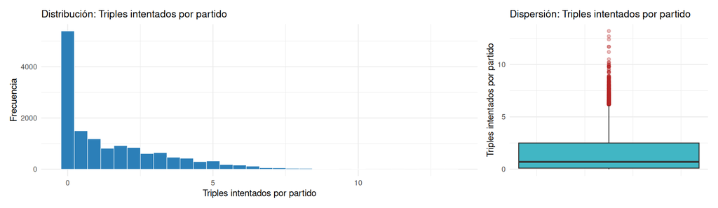

**Interpretación:** Intentos de triple por partido. Estadísticamente presenta una asimetría fuerte hacia la derecha: la mayoría de registros se concentra en valores bajos y una minoría se aleja mucho hacia arriba (asimetría = 1.42). No presenta valores NA. En el panel de variables clave queda representada por `porc_intentos_triple` (r = 0.77).

### 8.11.10 Porcentaje de triple (`porc_triple`)

| Media | Mediana | Desviación estándar | Mínimo | Máximo | Asimetría | Valores NA |
| --- | --- | --- | --- | --- | --- | --- |
| 0.263 | 0.31 | 0.162 | 0 | 1 | 0.108 | 1557 |

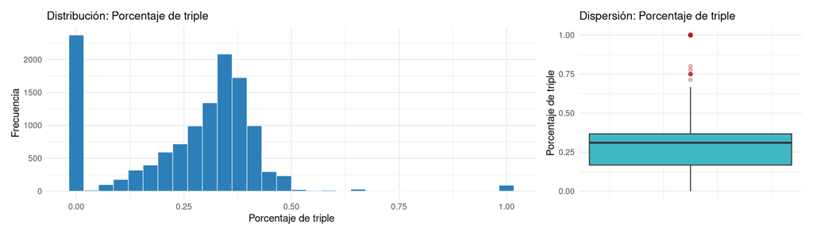

**Interpretación:** Porcentaje de acierto en triples. Estadísticamente presenta una distribución aproximadamente simétrica (asimetría = 0.11). Presenta 1,557 valores NA (11.1%), consistentes con el patrón estructural de porcentajes 0/0 documentado en la sección de calidad de datos. En el panel de variables clave queda representada por `porc_intentos_triple` (r = 0.51).

### 8.11.11 Tiros de 2 anotados por partido (`dobles_anotados_pp`)

| Media | Mediana | Desviación estándar | Mínimo | Máximo | Asimetría | Valores NA |
| --- | --- | --- | --- | --- | --- | --- |
| 3.035 | 2.5 | 2.119 | 0 | 13.2 | 1.077 | 0 |

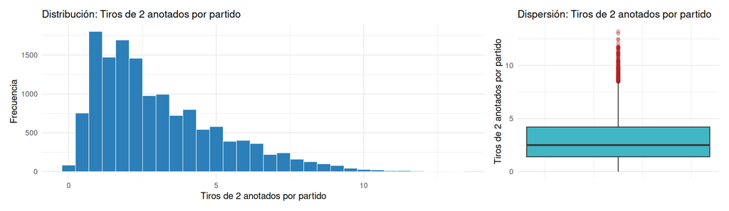

**Interpretación:** Tiros de 2 puntos anotados por partido. Estadísticamente presenta una asimetría fuerte hacia la derecha: la mayoría de registros se concentra en valores bajos y una minoría se aleja mucho hacia arriba (asimetría = 1.08). No presenta valores NA. En el panel de variables clave queda representada por `puntos_pp` (r = 0.92).

### 8.11.12 Tiros de 2 intentados por partido (`dobles_intentados_pp`)

| Media | Mediana | Desviación estándar | Mínimo | Máximo | Asimetría | Valores NA |
| --- | --- | --- | --- | --- | --- | --- |
| 6.242 | 5.1 | 4.163 | 0 | 27 | 1.02 | 0 |

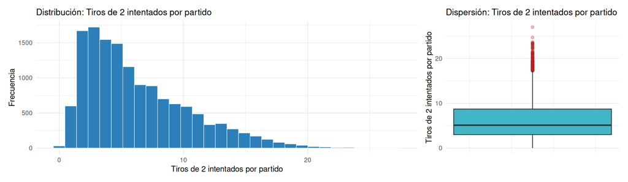

**Interpretación:** Intentos de tiro de 2 puntos por partido. Estadísticamente presenta una asimetría fuerte hacia la derecha: la mayoría de registros se concentra en valores bajos y una minoría se aleja mucho hacia arriba (asimetría = 1.02). No presenta valores NA. En el panel de variables clave queda representada por `puntos_pp` (r = 0.91).

### 8.11.13 Porcentaje de tiro de 2 puntos (`porc_doble`)

| Media | Mediana | Desviación estándar | Mínimo | Máximo | Asimetría | Valores NA |
| --- | --- | --- | --- | --- | --- | --- |
| 0.478 | 0.477 | 0.066 | 0 | 0.897 | -0.067 | 1 |

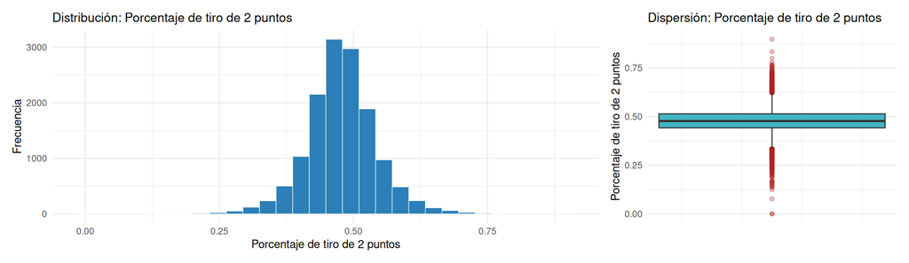

**Interpretación:** Porcentaje de acierto en tiros de 2 puntos. Estadísticamente presenta una distribución aproximadamente simétrica (asimetría = -0.07). Presenta 1 valores NA (0.0%), consistentes con el patrón estructural de porcentajes 0/0 documentado en la sección de calidad de datos. En el panel de variables clave queda representada por `porc_tiro_verdadero` (r = 0.79).

### 8.11.14 Porcentaje de tiro efectivo (eFG%) (`porc_tiro_efectivo`)

| Media | Mediana | Desviación estándar | Mínimo | Máximo | Asimetría | Valores NA |
| --- | --- | --- | --- | --- | --- | --- |
| 0.486 | 0.487 | 0.061 | 0.15 | 0.778 | -0.186 | 0 |

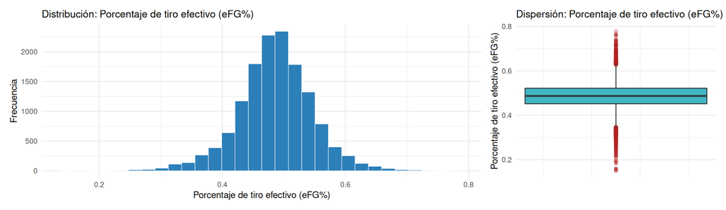

**Interpretación:** Porcentaje de tiro efectivo (pondera el mayor valor del triple). Estadísticamente presenta una distribución aproximadamente simétrica (asimetría = -0.19). No presenta valores NA. En el panel de variables clave queda representada por `porc_tiro_verdadero` (r = 0.94).

### 8.11.15 Tiros libres anotados por partido (`libres_anotados_pp`)

| Media | Mediana | Desviación estándar | Mínimo | Máximo | Asimetría | Valores NA |
| --- | --- | --- | --- | --- | --- | --- |
| 1.766 | 1.3 | 1.471 | 0 | 10.3 | 1.613 | 0 |

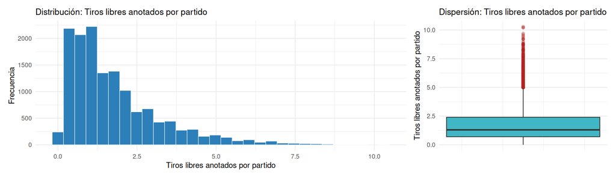

**Interpretación:** Tiros libres anotados por partido. Estadísticamente presenta una asimetría fuerte hacia la derecha: la mayoría de registros se concentra en valores bajos y una minoría se aleja mucho hacia arriba (asimetría = 1.61). No presenta valores NA.

### 8.11.16 Tiros libres intentados por partido (`libres_intentados_pp`)

| Media | Mediana | Desviación estándar | Mínimo | Máximo | Asimetría | Valores NA |
| --- | --- | --- | --- | --- | --- | --- |
| 2.348 | 1.8 | 1.853 | 0 | 13.1 | 1.562 | 0 |

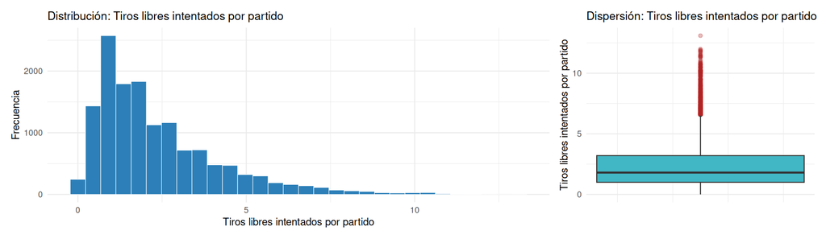

**Interpretación:** Intentos de tiro libre por partido. Estadísticamente presenta una asimetría fuerte hacia la derecha: la mayoría de registros se concentra en valores bajos y una minoría se aleja mucho hacia arriba (asimetría = 1.56). No presenta valores NA.

### 8.11.17 Porcentaje de tiro libre (`porc_libre`)

| Media | Mediana | Desviación estándar | Mínimo | Máximo | Asimetría | Valores NA |
| --- | --- | --- | --- | --- | --- | --- |
| 0.734 | 0.753 | 0.118 | 0 | 1 | -1.137 | 20 |

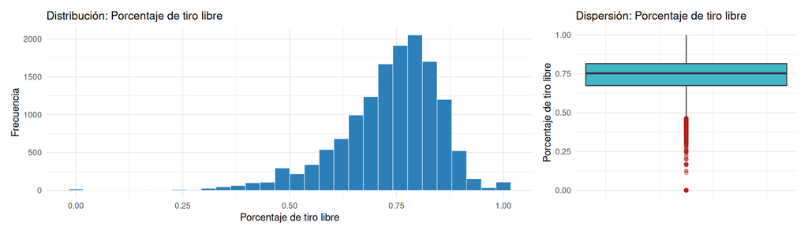

**Interpretación:** Porcentaje de acierto en tiros libres. Estadísticamente presenta una asimetría fuerte hacia la izquierda: la mayoría de registros se concentra en valores altos y una minoría se aleja mucho hacia abajo (asimetría = -1.14). Presenta 20 valores NA (0.1%), consistentes con el patrón estructural de porcentajes 0/0 documentado en la sección de calidad de datos.

### 8.11.18 Rebotes ofensivos por partido (`rebotes_of_pp`)

| Media | Mediana | Desviación estándar | Mínimo | Máximo | Asimetría | Valores NA |
| --- | --- | --- | --- | --- | --- | --- |
| 1.134 | 0.9 | 0.88 | 0 | 6.9 | 1.353 | 0 |

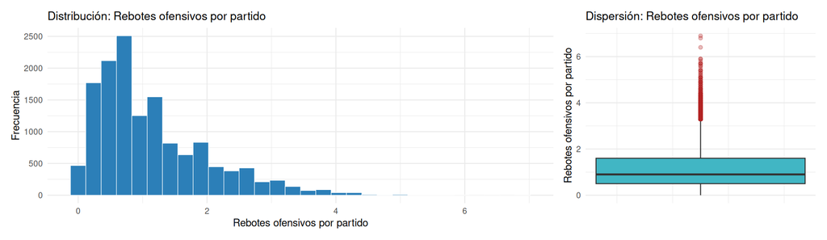

**Interpretación:** Rebotes ofensivos por partido. Estadísticamente presenta una asimetría fuerte hacia la derecha: la mayoría de registros se concentra en valores bajos y una minoría se aleja mucho hacia arriba (asimetría = 1.35). No presenta valores NA. En el panel de variables clave queda representada por `porc_rebotes_tot_disp` (r = 0.73).

### 8.11.19 Rebotes defensivos por partido (`rebotes_def_pp`)

| Media | Mediana | Desviación estándar | Mínimo | Máximo | Asimetría | Valores NA |
| --- | --- | --- | --- | --- | --- | --- |
| 2.843 | 2.4 | 1.821 | 0.1 | 12.3 | 1.272 | 0 |

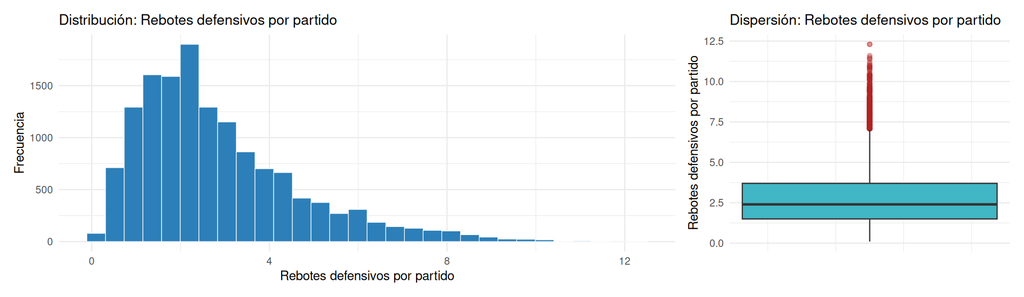

**Interpretación:** Rebotes defensivos por partido. Estadísticamente presenta una asimetría fuerte hacia la derecha: la mayoría de registros se concentra en valores bajos y una minoría se aleja mucho hacia arriba (asimetría = 1.27). No presenta valores NA. En el panel de variables clave queda representada por `porc_rebotes_tot_disp` (r = 0.61).

### 8.11.20 Rebotes totales por partido (`rebotes_totales_pp`)

| Media | Mediana | Desviación estándar | Mínimo | Máximo | Asimetría | Valores NA |
| --- | --- | --- | --- | --- | --- | --- |
| 3.975 | 3.3 | 2.564 | 0.1 | 18.7 | 1.256 | 0 |

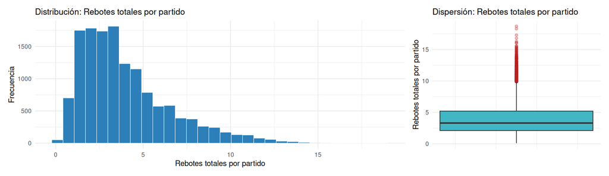

**Interpretación:** Rebotes totales por partido (= rebotes_of_pp + rebotes_def_pp). Estadísticamente presenta una asimetría fuerte hacia la derecha: la mayoría de registros se concentra en valores bajos y una minoría se aleja mucho hacia arriba (asimetría = 1.26). No presenta valores NA. En el panel de variables clave queda representada por `porc_rebotes_tot_disp` (r = 0.68).

### 8.11.21 Asistencias por partido (`asistencias_pp`)

| Media | Mediana | Desviación estándar | Mínimo | Máximo | Asimetría | Valores NA |
| --- | --- | --- | --- | --- | --- | --- |
| 2.119 | 1.5 | 1.94 | 0 | 14.5 | 1.808 | 0 |

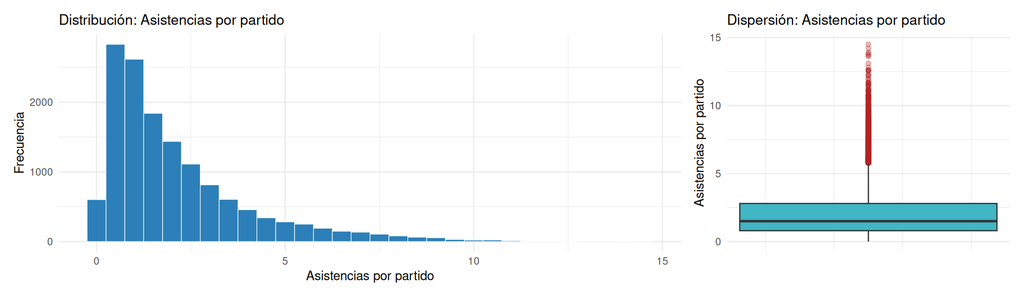

**Interpretación:** Asistencias por partido. Estadísticamente presenta una asimetría fuerte hacia la derecha: la mayoría de registros se concentra en valores bajos y una minoría se aleja mucho hacia arriba (asimetría = 1.81). No presenta valores NA. En el panel de variables clave queda representada por `porc_asistencias_equipo` (r = 0.89).

### 8.11.22 Robos por partido (`robos_pp`)

| Media | Mediana | Desviación estándar | Mínimo | Máximo | Asimetría | Valores NA |
| --- | --- | --- | --- | --- | --- | --- |
| 0.739 | 0.6 | 0.469 | 0 | 3.7 | 1.176 | 0 |

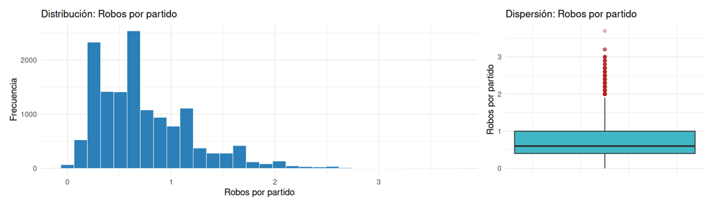

**Interpretación:** Robos de balón por partido. Estadísticamente presenta una asimetría fuerte hacia la derecha: la mayoría de registros se concentra en valores bajos y una minoría se aleja mucho hacia arriba (asimetría = 1.18). No presenta valores NA.

### 8.11.23 Tapones (bloqueos) por partido (`tapones_pp`)

| Media | Mediana | Desviación estándar | Mínimo | Máximo | Asimetría | Valores NA |
| --- | --- | --- | --- | --- | --- | --- |
| 0.471 | 0.3 | 0.528 | 0 | 5.6 | 2.57 | 0 |

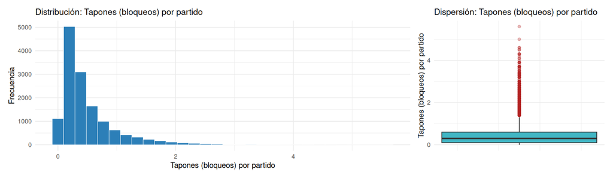

**Interpretación:** Bloqueos por partido. Estadísticamente presenta una asimetría fuerte hacia la derecha: la mayoría de registros se concentra en valores bajos y una minoría se aleja mucho hacia arriba (asimetría = 2.57). No presenta valores NA.

### 8.11.24 Pérdidas de balón por partido (`perdidas_pp`)

| Media | Mediana | Desviación estándar | Mínimo | Máximo | Asimetría | Valores NA |
| --- | --- | --- | --- | --- | --- | --- |
| 1.368 | 1.2 | 0.819 | 0 | 5.7 | 0.94 | 0 |

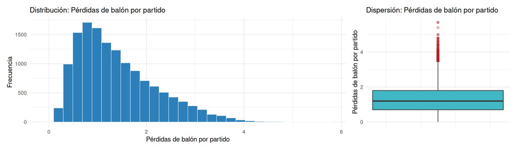

**Interpretación:** Pérdidas de balón por partido. Estadísticamente presenta una asimetría moderada hacia la derecha (cola de valores altos) (asimetría = 0.94). No presenta valores NA.

### 8.11.25 Faltas personales por partido (`faltas_pp`)

| Media | Mediana | Desviación estándar | Mínimo | Máximo | Asimetría | Valores NA |
| --- | --- | --- | --- | --- | --- | --- |
| 2.078 | 2.1 | 0.78 | 0.2 | 4.9 | 0.168 | 0 |

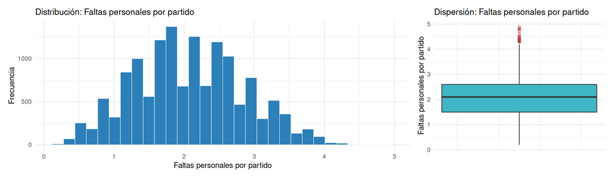

**Interpretación:** Faltas personales por partido. Estadísticamente presenta una distribución aproximadamente simétrica (asimetría = 0.17). No presenta valores NA.

### 8.11.26 Player Efficiency Rating (PER) (`indice_eficiencia`)

| Media | Mediana | Desviación estándar | Mínimo | Máximo | Asimetría | Valores NA |
| --- | --- | --- | --- | --- | --- | --- |
| 13.613 | 13.3 | 4.462 | -4.8 | 32.8 | 0.422 | 0 |

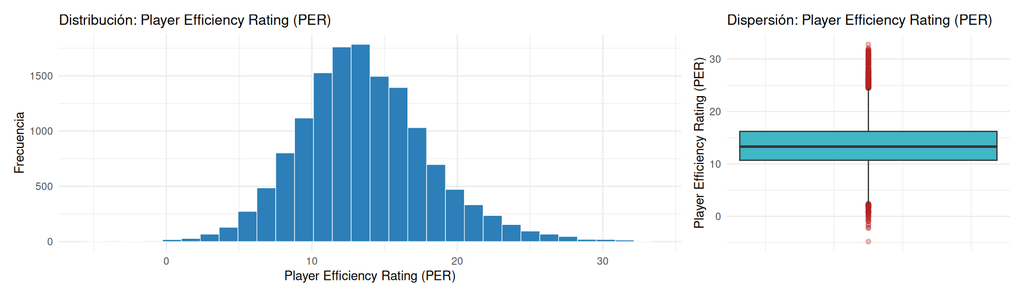

**Interpretación:** Player Efficiency Rating: índice compuesto de eficiencia por minuto, ajustado por ritmo (15.0 = promedio de liga). Estadísticamente presenta una distribución aproximadamente simétrica (asimetría = 0.42). No presenta valores NA. En el panel de variables clave queda representada por `valor_sobre_reemplazo` (r = 0.78).

### 8.11.27 Razón libres intentados / tiros de campo intentados (`razon_libres_intentos`)

| Media | Mediana | Desviación estándar | Mínimo | Máximo | Asimetría | Valores NA |
| --- | --- | --- | --- | --- | --- | --- |
| 0.307 | 0.284 | 0.148 | 0 | 1.5 | 1.219 | 0 |

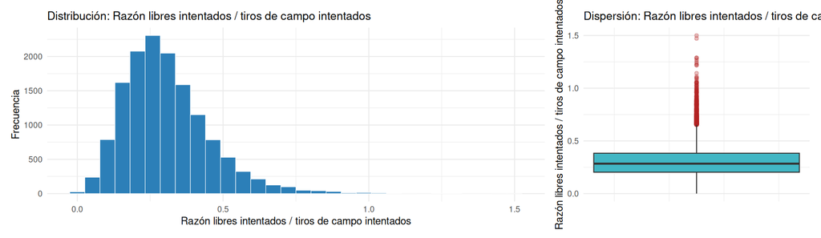

**Interpretación:** Razón entre intentos de tiro libre e intentos de campo. Estadísticamente presenta una asimetría fuerte hacia la derecha: la mayoría de registros se concentra en valores bajos y una minoría se aleja mucho hacia arriba (asimetría = 1.22). No presenta valores NA.

### 8.11.28 % de rebotes ofensivos disponibles capturados (`porc_rebotes_of_disp`)

| Media | Mediana | Desviación estándar | Mínimo | Máximo | Asimetría | Valores NA |
| --- | --- | --- | --- | --- | --- | --- |
| 5.948 | 5.1 | 3.875 | 0 | 24.2 | 0.679 | 0 |

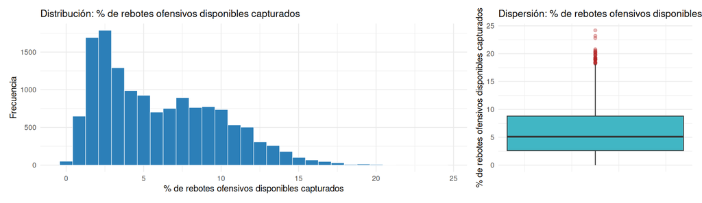

**Interpretación:** % estimado de rebotes ofensivos disponibles capturados mientras el jugador estuvo en cancha. Estadísticamente presenta una asimetría moderada hacia la derecha (cola de valores altos) (asimetría = 0.68). No presenta valores NA. En el panel de variables clave queda representada por `porc_rebotes_tot_disp` (r = 0.88).

### 8.11.29 % de rebotes defensivos disponibles capturados (`porc_rebotes_def_disp`)

| Media | Mediana | Desviación estándar | Mínimo | Máximo | Asimetría | Valores NA |
| --- | --- | --- | --- | --- | --- | --- |
| 14.209 | 13.3 | 5.833 | 1.1 | 40 | 0.624 | 0 |

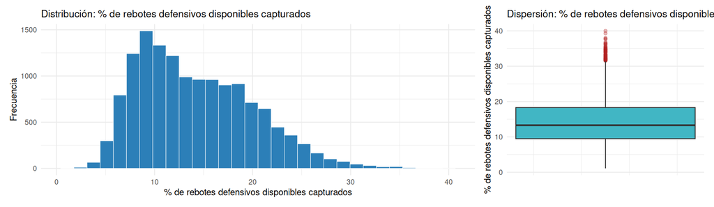

**Interpretación:** % estimado de rebotes defensivos disponibles capturados. Estadísticamente presenta una asimetría moderada hacia la derecha (cola de valores altos) (asimetría = 0.62). No presenta valores NA. En el panel de variables clave queda representada por `porc_rebotes_tot_disp` (r = 0.95).

### 8.11.30 % de posesiones rivales terminadas en robo (`porc_robos_equipo`)

| Media | Mediana | Desviación estándar | Mínimo | Máximo | Asimetría | Valores NA |
| --- | --- | --- | --- | --- | --- | --- |
| 1.636 | 1.5 | 0.695 | 0 | 5.9 | 0.837 | 0 |

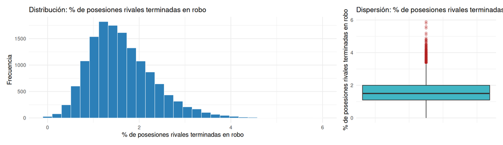

**Interpretación:** % estimado de posesiones rivales que terminaron en robo del jugador. Estadísticamente presenta una asimetría moderada hacia la derecha (cola de valores altos) (asimetría = 0.84). No presenta valores NA.

### 8.11.31 % de tiros de 2 rivales bloqueados (`porc_tapones_equipo`)

| Media | Mediana | Desviación estándar | Mínimo | Máximo | Asimetría | Valores NA |
| --- | --- | --- | --- | --- | --- | --- |
| 1.57 | 1 | 1.556 | 0 | 13.7 | 1.887 | 0 |

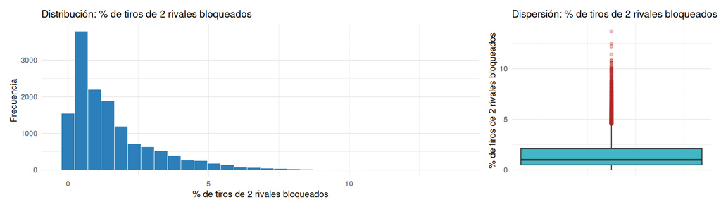

**Interpretación:** % estimado de tiros de campo rivales de 2 puntos bloqueados por el jugador. Estadísticamente presenta una asimetría fuerte hacia la derecha: la mayoría de registros se concentra en valores bajos y una minoría se aleja mucho hacia arriba (asimetría = 1.89). No presenta valores NA.

### 8.11.32 Pérdidas por cada 100 jugadas individuales (`porc_perdidas_jugada`)

| Media | Mediana | Desviación estándar | Mínimo | Máximo | Asimetría | Valores NA |
| --- | --- | --- | --- | --- | --- | --- |
| 14.151 | 13.6 | 4.472 | 0 | 57.1 | 0.982 | 0 |

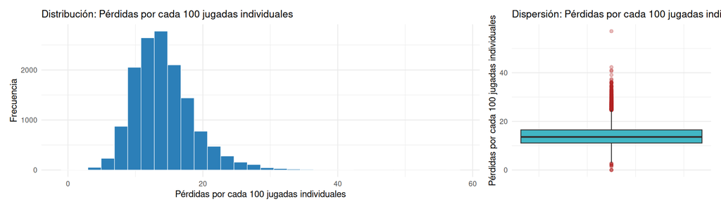

**Interpretación:** Pérdidas de balón estimadas por cada 100 jugadas individuales. Estadísticamente presenta una asimetría moderada hacia la derecha (cola de valores altos) (asimetría = 0.98). No presenta valores NA.

### 8.11.33 Win Shares ofensivos (`victorias_ofensiva`)

| Media | Mediana | Desviación estándar | Mínimo | Máximo | Asimetría | Valores NA |
| --- | --- | --- | --- | --- | --- | --- |
| 1.644 | 1 | 2.215 | -3.3 | 15.2 | 1.685 | 0 |

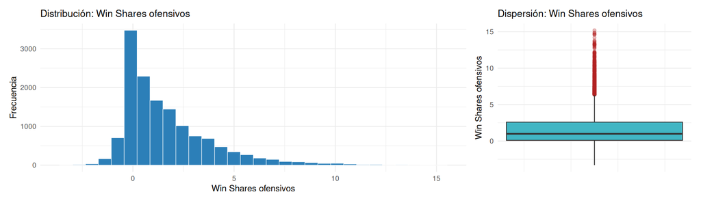

**Interpretación:** Win Shares ofensivos: victorias atribuidas a la contribución ofensiva del jugador. Estadísticamente presenta una asimetría fuerte hacia la derecha: la mayoría de registros se concentra en valores bajos y una minoría se aleja mucho hacia arriba (asimetría = 1.68). No presenta valores NA. En el panel de variables clave queda representada por `valor_sobre_reemplazo` (r = 0.89).

### 8.11.34 Win Shares defensivos (`victorias_defensa`)

| Media | Mediana | Desviación estándar | Mínimo | Máximo | Asimetría | Valores NA |
| --- | --- | --- | --- | --- | --- | --- |
| 1.494 | 1.2 | 1.242 | -1 | 9.1 | 1.248 | 0 |

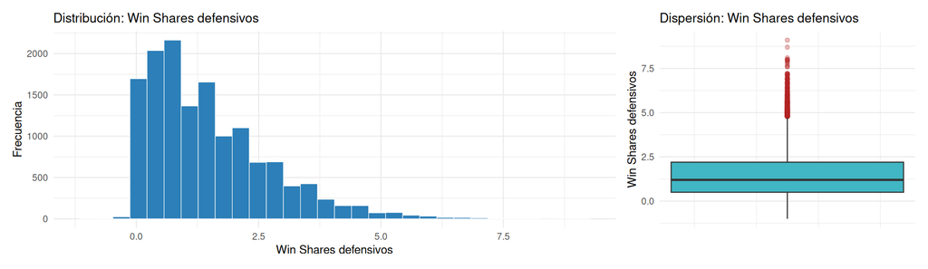

**Interpretación:** Win Shares defensivos. Estadísticamente presenta una asimetría fuerte hacia la derecha: la mayoría de registros se concentra en valores bajos y una minoría se aleja mucho hacia arriba (asimetría = 1.25). No presenta valores NA. En el panel de variables clave queda representada por `valor_sobre_reemplazo` (r = 0.72).

### 8.11.35 Win Shares totales (`victorias_total`)

| Media | Mediana | Desviación estándar | Mínimo | Máximo | Asimetría | Valores NA |
| --- | --- | --- | --- | --- | --- | --- |
| 3.138 | 2.3 | 3.117 | -2.1 | 21.2 | 1.393 | 0 |

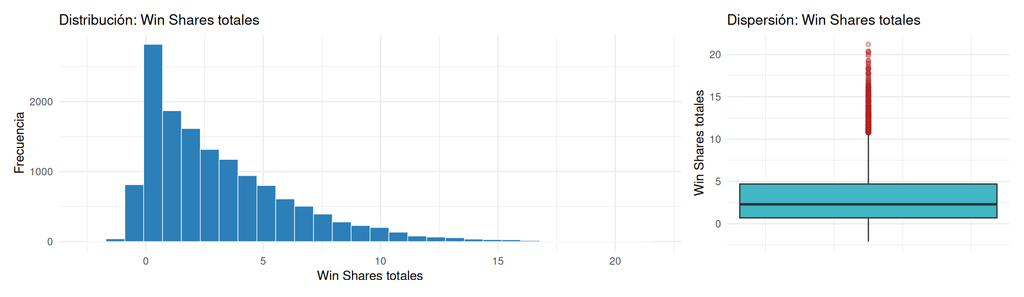

**Interpretación:** Win Shares totales (= victorias_ofensiva + victorias_defensa). Estadísticamente presenta una asimetría fuerte hacia la derecha: la mayoría de registros se concentra en valores bajos y una minoría se aleja mucho hacia arriba (asimetría = 1.39). No presenta valores NA. En el panel de variables clave queda representada por `valor_sobre_reemplazo` (r = 0.92).

### 8.11.36 Win Shares por 48 minutos (`victorias_por_48min`)

| Media | Mediana | Desviación estándar | Mínimo | Máximo | Asimetría | Valores NA |
| --- | --- | --- | --- | --- | --- | --- |
| 0.087 | 0.088 | 0.06 | -0.263 | 0.325 | -0.087 | 0 |

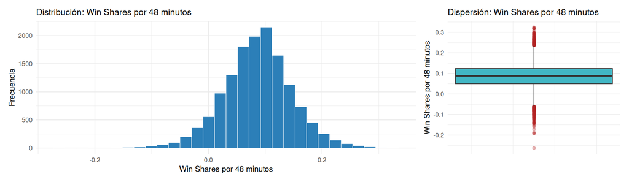

**Interpretación:** Win Shares por cada 48 minutos (ritmo de un partido completo). Estadísticamente presenta una distribución aproximadamente simétrica (asimetría = -0.09). No presenta valores NA. En el panel de variables clave queda representada por `valor_sobre_reemplazo` (r = 0.72).

### 8.11.37 Box Plus/Minus ofensivo (`masmenos_ofensivo`)

| Media | Mediana | Desviación estándar | Mínimo | Máximo | Asimetría | Valores NA |
| --- | --- | --- | --- | --- | --- | --- |
| -0.928 | -1 | 2.659 | -11.6 | 10.3 | 0.17 | 0 |

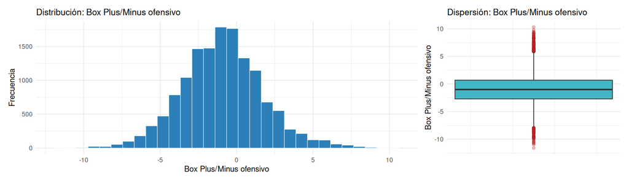

**Interpretación:** Box Plus/Minus ofensivo (puntos por 100 posesiones sobre el jugador promedio de liga). Estadísticamente presenta una distribución aproximadamente simétrica (asimetría = 0.17). No presenta valores NA. En el panel de variables clave queda representada por `valor_sobre_reemplazo` (r = 0.8).

### 8.11.38 Box Plus/Minus total (`masmenos_total`)

| Media | Mediana | Desviación estándar | Mínimo | Máximo | Asimetría | Valores NA |
| --- | --- | --- | --- | --- | --- | --- |
| -0.976 | -1 | 3.038 | -16.4 | 13.7 | 0.187 | 0 |

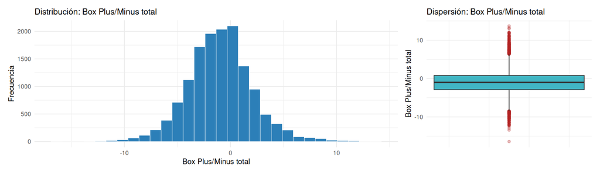

**Interpretación:** Box Plus/Minus total (= masmenos_ofensivo + masmenos_defensivo). Estadísticamente presenta una distribución aproximadamente simétrica (asimetría = 0.19). No presenta valores NA. En el panel de variables clave queda representada por `valor_sobre_reemplazo` (r = 0.85).

### 8.11.39 Margen de victoria del equipo (`margen_victoria`)

| Media | Mediana | Desviación estándar | Mínimo | Máximo | Asimetría | Valores NA |
| --- | --- | --- | --- | --- | --- | --- |
| -0.025 | 0.26 | 4.697 | -15.2 | 12.24 | -0.225 | 0 |

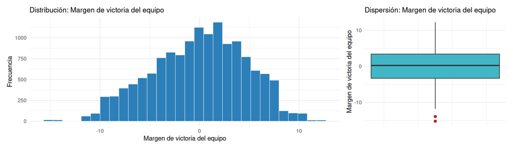

**Interpretación:** Margen de victoria promedio del equipo del jugador esa temporada (diferencia de puntos por partido). Estadísticamente presenta una distribución aproximadamente simétrica (asimetría = -0.23). No presenta valores NA. En el panel de variables clave queda representada por `porc_victorias_equipo` (r = 0.97).

### 8.11.40 Margen de victoria ajustado por calendario (`margen_victoria_ajust`)

| Media | Mediana | Desviación estándar | Mínimo | Máximo | Asimetría | Valores NA |
| --- | --- | --- | --- | --- | --- | --- |
| -0.025 | 0.16 | 4.538 | -14.68 | 11.8 | -0.227 | 0 |

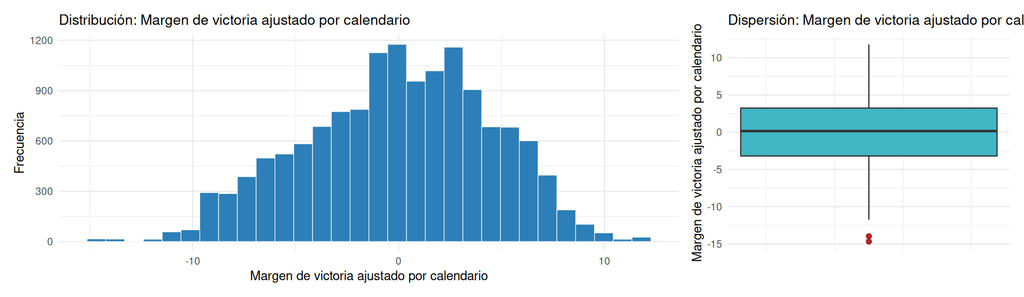

**Interpretación:** Margen de victoria del equipo, ajustado por fuerza de calendario. Estadísticamente presenta una distribución aproximadamente simétrica (asimetría = -0.23). No presenta valores NA. En el panel de variables clave queda representada por `porc_victorias_equipo` (r = 0.97).

## 8.12 Resumen numérico consolidado

Resumen numérico completo de **todas** las variables numéricas (las 10 claves aparecen marcadas), útil como tabla de referencia única.

```r
map_dfr(vars_numericas, function(v) {
  bind_cols(Variable = v, Clave = ifelse(v %in% vars_clave, "★", ""), tabla_stats(df[[v]]))
}) %>%
  arrange(desc(Clave), Variable) %>%
  kable(
    digits = 3,
    col.names = c("Variable", "Clave", nombres_stats),
    caption = "Resumen numérico de todas las variables numéricas (★ = variable clave)"
  ) %>%
  kable_styling(
    bootstrap_options = c("striped", "hover", "condensed"),
    font_size = 11
  ) %>%
  row_spec(seq_len(length(vars_clave)), bold = TRUE, background = "#EAF3F7")
```

Resumen numérico de todas las variables numéricas (★ = variable clave)

| Variable | Clave | Media | Mediana | Desviación estándar | Mínimo | Máximo | Asimetría | Valores NA |
| --- | --- | --- | --- | --- | --- | --- | --- | --- |
| masmenos_defensivo | ★ | -0.048 | -0.100 | 1.214 | -6.700 | 5.500 | 0.283 | 0 |
| minutos_totales | ★ | 1442.599 | 1407.000 | 867.389 | 100.000 | 3533.000 | 0.185 | 0 |
| porc_asistencias_equipo | ★ | 13.547 | 10.700 | 9.160 | 0.000 | 57.500 | 1.239 | 0 |
| porc_intentos_triple | ★ | 0.190 | 0.113 | 0.201 | 0.000 | 1.000 | 0.874 | 0 |
| porc_rebotes_tot_disp | ★ | 10.079 | 9.300 | 4.481 | 1.000 | 29.700 | 0.566 | 0 |
| porc_tiro_verdadero | ★ | 0.525 | 0.528 | 0.059 | 0.184 | 0.746 | -0.437 | 0 |
| porc_uso_jugador | ★ | 18.905 | 18.600 | 4.974 | 3.700 | 41.700 | 0.378 | 0 |
| porc_victorias_equipo | ★ | 0.499 | 0.512 | 0.155 | 0.106 | 0.890 | -0.180 | 0 |
| puntos_pp | ★ | 9.405 | 7.900 | 6.098 | 0.300 | 37.100 | 0.952 | 0 |
| valor_sobre_reemplazo | ★ | 0.781 | 0.300 | 1.476 | -2.600 | 12.500 | 2.173 | 0 |
| asistencias_pp |  | 2.119 | 1.500 | 1.940 | 0.000 | 14.500 | 1.808 | 0 |
| dobles_anotados_pp |  | 3.035 | 2.500 | 2.119 | 0.000 | 13.200 | 1.077 | 0 |
| dobles_intentados_pp |  | 6.242 | 5.100 | 4.163 | 0.000 | 27.000 | 1.020 | 0 |
| edad |  | 26.686 | 26.000 | 4.142 | 18.000 | 43.000 | 0.558 | 0 |
| faltas_pp |  | 2.078 | 2.100 | 0.780 | 0.200 | 4.900 | 0.168 | 0 |
| indice_eficiencia |  | 13.613 | 13.300 | 4.462 | -4.800 | 32.800 | 0.422 | 0 |
| libres_anotados_pp |  | 1.766 | 1.300 | 1.471 | 0.000 | 10.300 | 1.613 | 0 |
| libres_intentados_pp |  | 2.348 | 1.800 | 1.853 | 0.000 | 13.100 | 1.562 | 0 |
| margen_victoria |  | -0.025 | 0.260 | 4.697 | -15.200 | 12.240 | -0.225 | 0 |
| margen_victoria_ajust |  | -0.025 | 0.160 | 4.538 | -14.680 | 11.800 | -0.227 | 0 |
| masmenos_ofensivo |  | -0.928 | -1.000 | 2.659 | -11.600 | 10.300 | 0.170 | 0 |
| masmenos_total |  | -0.976 | -1.000 | 3.038 | -16.400 | 13.700 | 0.187 | 0 |
| minutos_pp |  | 22.412 | 22.200 | 9.414 | 3.000 | 43.700 | 0.032 | 0 |
| partidos_jugados |  | 59.791 | 66.000 | 20.613 | 3.000 | 82.000 | -0.815 | 0 |
| partidos_titular |  | 30.408 | 18.000 | 30.112 | 0.000 | 82.000 | 0.524 | 0 |
| perdidas_pp |  | 1.368 | 1.200 | 0.819 | 0.000 | 5.700 | 0.940 | 0 |
| porc_doble |  | 0.478 | 0.477 | 0.066 | 0.000 | 0.897 | -0.067 | 1 |
| porc_libre |  | 0.734 | 0.753 | 0.118 | 0.000 | 1.000 | -1.137 | 20 |
| porc_perdidas_jugada |  | 14.151 | 13.600 | 4.472 | 0.000 | 57.100 | 0.982 | 0 |
| porc_rebotes_def_disp |  | 14.209 | 13.300 | 5.833 | 1.100 | 40.000 | 0.624 | 0 |
| porc_rebotes_of_disp |  | 5.948 | 5.100 | 3.875 | 0.000 | 24.200 | 0.679 | 0 |
| porc_robos_equipo |  | 1.636 | 1.500 | 0.695 | 0.000 | 5.900 | 0.837 | 0 |
| porc_tapones_equipo |  | 1.570 | 1.000 | 1.556 | 0.000 | 13.700 | 1.887 | 0 |
| porc_tiro_campo |  | 0.454 | 0.451 | 0.064 | 0.150 | 0.778 | 0.213 | 0 |
| porc_tiro_efectivo |  | 0.486 | 0.487 | 0.061 | 0.150 | 0.778 | -0.186 | 0 |
| porc_triple |  | 0.263 | 0.310 | 0.162 | 0.000 | 1.000 | 0.108 | 1557 |
| razon_libres_intentos |  | 0.307 | 0.284 | 0.148 | 0.000 | 1.500 | 1.219 | 0 |
| rebotes_def_pp |  | 2.843 | 2.400 | 1.821 | 0.100 | 12.300 | 1.272 | 0 |
| rebotes_of_pp |  | 1.134 | 0.900 | 0.880 | 0.000 | 6.900 | 1.353 | 0 |
| rebotes_totales_pp |  | 3.975 | 3.300 | 2.564 | 0.100 | 18.700 | 1.256 | 0 |
| robos_pp |  | 0.739 | 0.600 | 0.469 | 0.000 | 3.700 | 1.176 | 0 |
| tapones_pp |  | 0.471 | 0.300 | 0.528 | 0.000 | 5.600 | 2.570 | 0 |
| temporada |  | 2003.335 | 2004.000 | 11.637 | 1982.000 | 2022.000 | -0.121 | 0 |
| tiros_anotados_pp |  | 3.559 | 3.000 | 2.266 | 0.100 | 13.400 | 0.887 | 0 |
| tiros_intentados_pp |  | 7.737 | 6.700 | 4.688 | 0.400 | 27.800 | 0.823 | 0 |
| triples_anotados_pp |  | 0.523 | 0.200 | 0.685 | 0.000 | 5.300 | 1.566 | 0 |
| triples_intentados_pp |  | 1.495 | 0.700 | 1.807 | 0.000 | 13.200 | 1.418 | 0 |
| victorias_defensa |  | 1.494 | 1.200 | 1.242 | -1.000 | 9.100 | 1.248 | 0 |
| victorias_ofensiva |  | 1.644 | 1.000 | 2.215 | -3.300 | 15.200 | 1.685 | 0 |
| victorias_por_48min |  | 0.087 | 0.088 | 0.060 | -0.263 | 0.325 | -0.087 | 0 |
| victorias_total |  | 3.138 | 2.300 | 3.117 | -2.100 | 21.200 | 1.393 | 0 |

# 9 Análisis univariado de variables categóricas

Para las variables categóricas no se calculan promedios ni desviaciones estándar; en su lugar se analiza la **frecuencia y el peso relativo (%)** de cada categoría, apoyado en un gráfico de barras ordenado de mayor a menor.

```r
etiquetas_cat <- c(
  posicion = "Posición de juego",
  equipo = "Equipo / franquicia"
)

contexto_cat <- c(
  posicion = paste0(
    "permite comparar perfiles estadísticos por rol dentro de la cancha. ",
    "En el archivo depurado las 5 categorías están **notablemente ",
    "balanceadas** (ninguna se aparta mucho del 20% que correspondería a un ",
    "reparto perfecto), lo que las hace directamente comparables entre sí: ",
    "las diferencias que se observan en el boxplot por posición de la ",
    "sección 9 reflejan el rol en cancha, no un desequilibrio en el ",
    "tamaño de los grupos."
  ),
  equipo = paste0(
    "muestra qué franquicias concentran más temporadas-jugador en el ",
    "dataset y refleja 41 temporadas de historia de la NBA, incluyendo ",
    "reubicaciones y cambios de nombre de franquicias."
  )
)

nota_extra_cat <- c(
  posicion = paste0(
    "**Efecto de la depuración:** el archivo original contenía 17 ",
    "categorías, porque Basketball-Reference asigna posiciones híbridas ",
    "ponderadas por minutos (\"SG-PF\", \"SG-PG-SF\") a jugadores ",
    "multi-posicionales; varias de ellas tenían un puñado de casos, ",
    "insuficientes para cualquier comparación estadística. Al resolverlas ",
    "a la posición principal quedan 5 grupos limpios y de tamaño ",
    "comparable, que sí soportan un análisis por rol."
  ),
  equipo = paste0(
    "**Efecto de la depuración:** el código **\"TOT\"** (fila-resumen de ",
    "jugadores transferidos a mitad de temporada) era uno de los ",
    "\"equipos\" más frecuentes del archivo original y no correspondía a ",
    "ninguna franquicia real; al eliminarse, cualquier agregación por ",
    "equipo es ahora directa y no duplica minutos ya contabilizados. La ",
    "alta cardinalidad restante (40 códigos) refleja la historia real de ",
    "la liga: SEA (Seattle SuperSonics) pasó a ser OKC (Oklahoma City) en ",
    "2008; VAN (Vancouver Grizzlies) a MEM (Memphis) en 2001; WSB ",
    "(Washington Bullets) a WAS (Wizards) en 1997; y la franquicia de ",
    "Charlotte aparece como CHH, luego CHA y finalmente CHO. Por eso el ",
    "número de códigos (40) supera al de equipos activos en una ",
    "temporada cualquiera (30)."
  )
)

grafico_categorico <- function(v, etiqueta, top_n = 40) {

  tabla_frec <- df %>%
    count(.data[[v]], name = "n") %>%
    mutate(pct = n / sum(n) * 100) %>%
    arrange(desc(n)) %>%
    head(top_n)

  niveles_orden <- tabla_frec[[v]]

  ggplot(
    tabla_frec,
    aes(x = factor(.data[[v]], levels = rev(niveles_orden)), y = n)
  ) +
    geom_col(fill = col_barra, color = "white", alpha = 0.95) +
    geom_text(
      aes(label = paste0(comma(n), "  (", round(pct, 1), "%)")),
      hjust = -0.05, size = 3.1
    ) +
    coord_flip() +
    labs(
      title = paste("Distribución de", etiqueta),
      x = NULL, y = "Número de registros temporada-jugador"
    ) +
    scale_y_continuous(expand = expansion(mult = c(0, 0.22)), labels = comma) +
    theme_minimal(base_size = 11) +
    theme(
      plot.title = element_text(face = "bold", size = 13),
      panel.grid.major.y = element_blank()
    )
}
```

```r
for (v in vars_categoricas) {

  etiqueta <- etiquetas_cat[[v]]

  cat("\n\n## ", etiqueta, " (`", v, "`)\n\n", sep = "")

  tabla_frec <- df %>%
    count(.data[[v]], name = "Frecuencia") %>%
    mutate(Porcentaje = percent(Frecuencia / sum(Frecuencia), accuracy = 0.1)) %>%
    arrange(desc(Frecuencia))

  tabla_mostrar <- if (nrow(tabla_frec) > 15) head(tabla_frec, 15) else tabla_frec

  print(
    kable(
      tabla_mostrar,
      col.names = c(etiqueta, "Frecuencia", "% del total"),
      caption = if (nrow(tabla_frec) > 15) {
        paste0("Categorías más frecuentes (15 de ", nrow(tabla_frec), ")")
      } else {
        paste0("Todas las categorías (", nrow(tabla_frec), ")")
      }
    ) %>%
      kable_styling(bootstrap_options = c("striped", "condensed"), full_width = FALSE)
  )

  print(grafico_categorico(v, etiqueta))

  n_categorias <- nrow(tabla_frec)
  categoria_top <- as.character(tabla_frec[[v]][1])
  pct_top <- percent(tabla_frec$Frecuencia[1] / sum(tabla_frec$Frecuencia), accuracy = 0.1)
  pct_bottom <- percent(
    tabla_frec$Frecuencia[n_categorias] / sum(tabla_frec$Frecuencia),
    accuracy = 0.1
  )

  cat(
    "\n\n**Lectura académica:** la variable *", etiqueta, "* tiene **",
    n_categorias, "** categorías distintas. La más frecuente es **",
    categoria_top, "**, con **", pct_top, "** del total de registros, y la ",
    "menos frecuente concentra el **", pct_bottom, "**. Esta variable ",
    contexto_cat[[v]], "\n\n",
    sep = ""
  )

  cat(nota_extra_cat[[v]], "\n\n")
}
```

[output not shown]

## 9.1 Posición de juego (`posicion`)

Todas las categorías (5)

| Posición de juego | Frecuencia | % del total |
| --- | --- | --- |
| PF | 2924 | 20.8% |
| C | 2901 | 20.6% |
| SG | 2864 | 20.3% |
| SF | 2714 | 19.3% |
| PG | 2675 | 19.0% |

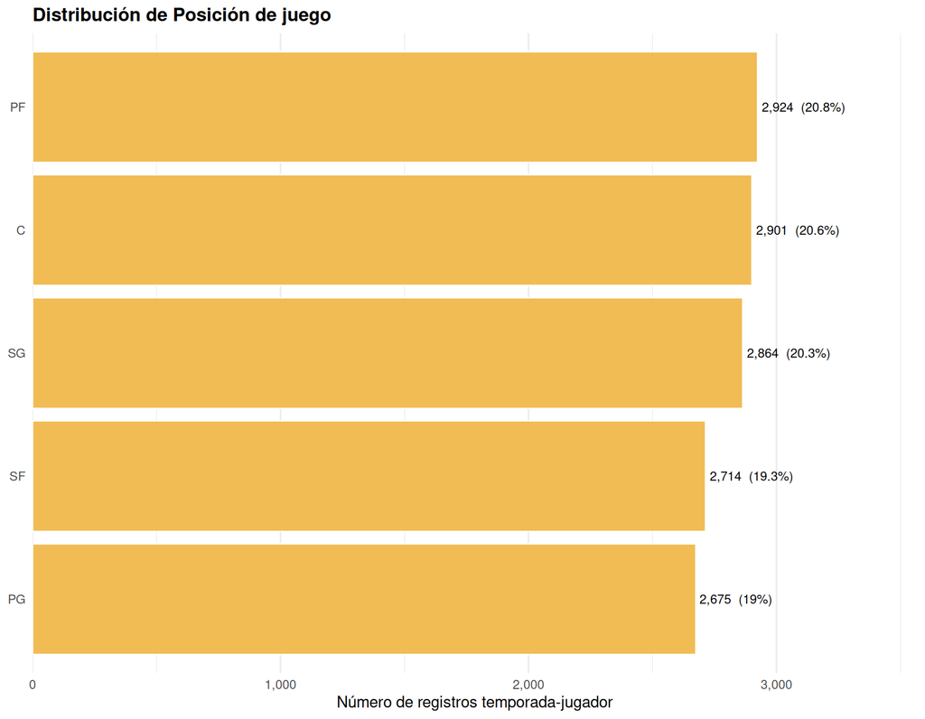

**Efecto de la depuración:** el archivo original contenía 17 categorías, porque Basketball-Reference asigna posiciones híbridas ponderadas por minutos (“SG-PF”, “SG-PG-SF”) a jugadores multi-posicionales; varias de ellas tenían un puñado de casos, insuficientes para cualquier comparación estadística. Al resolverlas a la posición principal quedan 5 grupos limpios y de tamaño comparable, que sí soportan un análisis por rol.

## 9.2 Equipo / franquicia (`equipo`)

Categorías más frecuentes (15 de 40)

| Equipo / franquicia | Frecuencia | % del total |
| --- | --- | --- |
| LAL | 522 | 3.7% |
| IND | 521 | 3.7% |
| SAS | 514 | 3.7% |
| UTA | 513 | 3.6% |
| ATL | 510 | 3.6% |
| GSW | 510 | 3.6% |
| CHI | 505 | 3.6% |
| BOS | 501 | 3.6% |
| DAL | 496 | 3.5% |
| MIL | 496 | 3.5% |
| LAC | 494 | 3.5% |
| DET | 492 | 3.5% |
| POR | 491 | 3.5% |
| DEN | 490 | 3.5% |
| NYK | 488 | 3.5% |

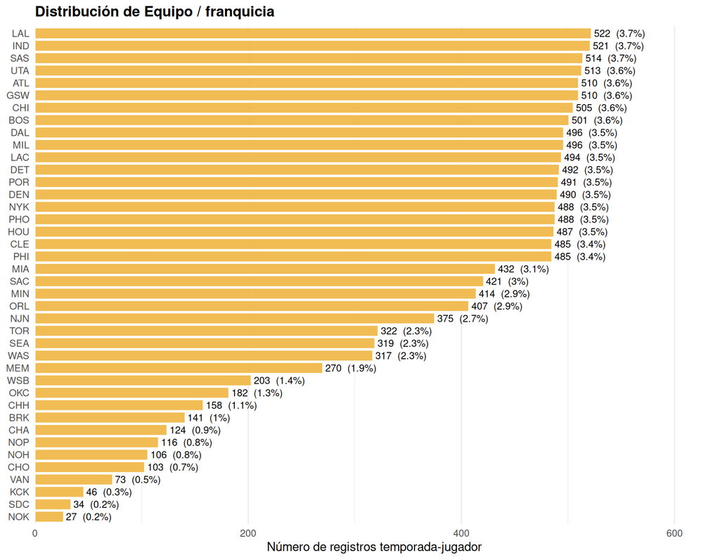

**Lectura académica:** la variable *Equipo / franquicia* tiene **40** categorías distintas. La más frecuente es **LAL**, con **3.7%** del total de registros, y la menos frecuente concentra el **0.2%**. Esta variable muestra qué franquicias concentran más temporadas-jugador en el dataset y refleja 41 temporadas de historia de la NBA, incluyendo reubicaciones y cambios de nombre de franquicias.

**Efecto de la depuración:** el código **“TOT”** (fila-resumen de jugadores transferidos a mitad de temporada) era uno de los “equipos” más frecuentes del archivo original y no correspondía a ninguna franquicia real; al eliminarse, cualquier agregación por equipo es ahora directa y no duplica minutos ya contabilizados. La alta cardinalidad restante (40 códigos) refleja la historia real de la liga: SEA (Seattle SuperSonics) pasó a ser OKC (Oklahoma City) en 2008; VAN (Vancouver Grizzlies) a MEM (Memphis) en 2001; WSB (Washington Bullets) a WAS (Wizards) en 1997; y la franquicia de Charlotte aparece como CHH, luego CHA y finalmente CHO. Por eso el número de códigos (40) supera al de equipos activos en una temporada cualquiera (30).

# 10 Estandarización y matriz de correlación

Esta sección es el puente entre el análisis univariado y el multivariado. Se realiza en dos pasos explícitos: primero se **estandarizan** todas las variables numéricas, y sobre esa matriz estandarizada se calcula e interpreta la **matriz de correlación**.

## 10.1 Por qué estandarizar

Las 51 variables numéricas de este dataset están en escalas radicalmente distintas, como se ve al compararlas directamente:

```r
df %>%
  select(all_of(vars_clave)) %>%
  map_dfr(
    ~ tibble(
      Media = mean(.x, na.rm = TRUE),
      Desv = sd(.x, na.rm = TRUE),
      Min = min(.x, na.rm = TRUE),
      Max = max(.x, na.rm = TRUE)
    ),
    .id = "Variable"
  ) %>%
  mutate(
    `Amplitud (Max - Min)` = Max - Min,
    Escala = c(
      "Victorias acumuladas", "Puntos por partido", "Minutos",
      "Fracción 0-1", "Puntos porcentuales 0-100", "Puntos porcentuales 0-100",
      "Puntos porcentuales 0-100", "Fracción 0-1", "Puntos por 100 posesiones",
      "Fracción 0-1"
    )
  ) %>%
  kable(
    digits = 3,
    caption = "Las 10 variables clave antes de estandarizar: escalas incomparables"
  ) %>%
  kable_styling(bootstrap_options = c("striped", "hover", "condensed"), font_size = 11) %>%
  column_spec(1, monospace = TRUE)
```

Las 10 variables clave antes de estandarizar: escalas incomparables

| Variable | Media | Desv | Min | Max | Amplitud (Max - Min) | Escala |
| --- | --- | --- | --- | --- | --- | --- |
| valor_sobre_reemplazo | 0.781 | 1.476 | -2.600 | 12.500 | 15.100 | Victorias acumuladas |
| puntos_pp | 9.405 | 6.098 | 0.300 | 37.100 | 36.800 | Puntos por partido |
| minutos_totales | 1442.599 | 867.389 | 100.000 | 3533.000 | 3433.000 | Minutos |
| porc_tiro_verdadero | 0.525 | 0.059 | 0.184 | 0.746 | 0.562 | Fracción 0-1 |
| porc_uso_jugador | 18.905 | 4.974 | 3.700 | 41.700 | 38.000 | Puntos porcentuales 0-100 |
| porc_rebotes_tot_disp | 10.079 | 4.481 | 1.000 | 29.700 | 28.700 | Puntos porcentuales 0-100 |
| porc_asistencias_equipo | 13.547 | 9.160 | 0.000 | 57.500 | 57.500 | Puntos porcentuales 0-100 |
| porc_intentos_triple | 0.190 | 0.201 | 0.000 | 1.000 | 1.000 | Fracción 0-1 |
| masmenos_defensivo | -0.048 | 1.214 | -6.700 | 5.500 | 12.200 | Puntos por 100 posesiones |
| porc_victorias_equipo | 0.499 | 0.155 | 0.106 | 0.890 | 0.784 | Fracción 0-1 |

La amplitud de `minutos_totales` se mide en **miles**, la de `porc_uso_jugador` en **decenas** y la de `porc_tiro_verdadero` en **centésimas**. Con escalas así, cualquier técnica basada en **distancias o en varianza** (PCA, clustering, k-means, regresión regularizada) quedaría completamente dominada por los minutos, simplemente porque sus números son más grandes — no porque la variable sea más importante. La solución estándar es la **estandarización** o *puntuación Z*:

$$z_{ij} = \frac{x_{ij} -
\bar{x}_j}{s_j}$$

donde cada variable $j$ se recentra en media 0 y se reescala a desviación estándar 1. Tras la transformación, **un punto = una desviación estándar en todas las variables**, lo que las hace directamente comparables.

```r
# ============================================================
# ESTANDARIZACIÓN (puntuación Z) DE TODAS LAS NUMÉRICAS
# ============================================================
# scale() resta la media y divide por la desviación estándar de cada
# columna, ignorando los NA en el cálculo de ambos estadísticos.

datos_numericos <- df %>%
  select(all_of(vars_numericas))

datos_estandarizados <- scale(datos_numericos)

# Verificación de que la transformación hizo lo que debía
verificacion_z <- tibble(
  Estadístico = c(
    "Variables estandarizadas",
    "Media máxima en valor absoluto (debe ser ~0)",
    "Desviación estándar mínima (debe ser 1)",
    "Desviación estándar máxima (debe ser 1)"
  ),
  Valor = c(
    as.character(ncol(datos_estandarizados)),
    format(max(abs(colMeans(datos_estandarizados, na.rm = TRUE))), digits = 3, scientific = TRUE),
    as.character(round(min(apply(datos_estandarizados, 2, sd, na.rm = TRUE)), 10)),
    as.character(round(max(apply(datos_estandarizados, 2, sd, na.rm = TRUE)), 10))
  )
)

verificacion_z %>%
  kable(caption = "Verificación de la estandarización") %>%
  kable_styling(bootstrap_options = c("striped", "condensed"), full_width = FALSE)
```

Verificación de la estandarización

| Estadístico | Valor |
| --- | --- |
| Variables estandarizadas | 51 |
| Media máxima en valor absoluto (debe ser ~0) | 1.63e-15 |
| Desviación estándar mínima (debe ser 1) | 1 |
| Desviación estándar máxima (debe ser 1) | 1 |

```r
comparacion <- bind_rows(
  df %>%
    select(all_of(vars_clave)) %>%
    map_dfr(~ tibble(Media = mean(.x, na.rm = TRUE), Desv = sd(.x, na.rm = TRUE)), .id = "Variable") %>%
    mutate(Estado = "Original"),
  as.data.frame(datos_estandarizados) %>%
    select(all_of(vars_clave)) %>%
    map_dfr(~ tibble(Media = mean(.x, na.rm = TRUE), Desv = sd(.x, na.rm = TRUE)), .id = "Variable") %>%
    mutate(Estado = "Estandarizada")
) %>%
  pivot_wider(names_from = Estado, values_from = c(Media, Desv))

comparacion %>%
  select(Variable, Media_Original, Desv_Original, Media_Estandarizada, Desv_Estandarizada) %>%
  kable(
    digits = 3,
    col.names = c("Variable", "Media (original)", "Desv. est. (original)",
                  "Media (estandarizada)", "Desv. est. (estandarizada)"),
    caption = "Las 10 variables clave antes y después de estandarizar"
  ) %>%
  kable_styling(bootstrap_options = c("striped", "hover", "condensed"), font_size = 11) %>%
  column_spec(1, monospace = TRUE) %>%
  column_spec(4:5, background = "#EAF3F7")
```

Las 10 variables clave antes y después de estandarizar

| Variable | Media (original) | Desv. est. (original) | Media (estandarizada) | Desv. est. (estandarizada) |
| --- | --- | --- | --- | --- |
| valor_sobre_reemplazo | 0.781 | 1.476 | 0 | 1 |
| puntos_pp | 9.405 | 6.098 | 0 | 1 |
| minutos_totales | 1442.599 | 867.389 | 0 | 1 |
| porc_tiro_verdadero | 0.525 | 0.059 | 0 | 1 |
| porc_uso_jugador | 18.905 | 4.974 | 0 | 1 |
| porc_rebotes_tot_disp | 10.079 | 4.481 | 0 | 1 |
| porc_asistencias_equipo | 13.547 | 9.160 | 0 | 1 |
| porc_intentos_triple | 0.190 | 0.201 | 0 | 1 |
| masmenos_defensivo | -0.048 | 1.214 | 0 | 1 |
| porc_victorias_equipo | 0.499 | 0.155 | 0 | 1 |

Tras la estandarización, las 10 variables clave —que antes tenían medias entre -0.05 y 1,443— comparten exactamente la misma media (0) y la misma desviación estándar (1). **Sobre esta matriz se calcula la correlación.**

## 10.2 Cálculo de la matriz sobre los datos estandarizados

```r
matriz_correlacion <- cor(
  datos_estandarizados,
  use = "pairwise.complete.obs"
)

# Comprobación: la correlación de Pearson es invariante a transformaciones
# lineales, por lo que debe coincidir con la calculada sobre los datos
# originales salvo error de redondeo de punto flotante.
matriz_sin_estandarizar <- cor(datos_numericos, use = "pairwise.complete.obs")
desvio_maximo <- max(abs(matriz_correlacion - matriz_sin_estandarizar), na.rm = TRUE)
```

**Nota metodológica sobre los NA.** Como se documentó en la sección de calidad de datos, tres columnas de porcentaje conservan `NA` estructurales (0 intentos). Usar `cor(..., use = "complete.obs")` (eliminación por caso completo) descartaría toda fila con **al menos uno** de esos `NA` — en la práctica, 1,577 de las 14,078 filas, solo porque un pívot nunca intentó un triple. Por eso se usa `use = "pairwise.complete.obs"`, que calcula cada correlación par a par con todas las observaciones disponibles para ese par concreto, preservando el máximo de información.

**Nota metodológica sobre la estandarización.** Conviene ser explícito sobre un punto que suele generar confusión: la **correlación de Pearson es invariante a transformaciones lineales**, de modo que correlacionar las variables estandarizadas da exactamente el mismo resultado que correlacionarlas en sus unidades originales. El desvío máximo entre ambas matrices en este dataset es de 1.11e-16 — es decir, cero salvo el error de redondeo de la aritmética de punto flotante. Esto **no hace inútil el paso de estandarización**, sino que aclara qué papel cumple:

- La correlación **ya es** una medida estandarizada por construcción ($r_{jk} = \operatorname{cov}(z_j, z_k)$): sobre datos en puntuación Z, la **matriz de correlación y la de covarianzas coinciden**, y cada celda se lee directamente como “cuántas desviaciones estándar se mueve una variable cuando la otra se mueve una”. Esa es la lectura correcta de los mapas de calor que siguen.
- La estandarización es **imprescindible** para los pasos siguientes del análisis multivariado (PCA, clustering, distancias), que sí dependen de la escala. Dejar la matriz `datos_estandarizados` construida y verificada es el insumo directo de esas técnicas.
- Trabajar sobre la matriz estandarizada hace el procedimiento **verificable**: la tabla anterior demuestra que las medias son 0 y las desviaciones 1, de modo que ninguna conclusión depende de una unidad de medida arbitraria.

## 10.3 Panorama general: las 51 variables

Con 51 variables, imprimir el coeficiente en cada una de las 2,601 celdas sería ilegible. Por eso este primer mapa de calor usa **solo el color** para la magnitud y el signo, y ordena las variables mediante **clustering jerárquico** sobre $1 - |r|$: las variables que se comportan de forma parecida quedan contiguas, de modo que los **bloques de color** que aparecen en la diagonal son grupos de variables redundantes entre sí.

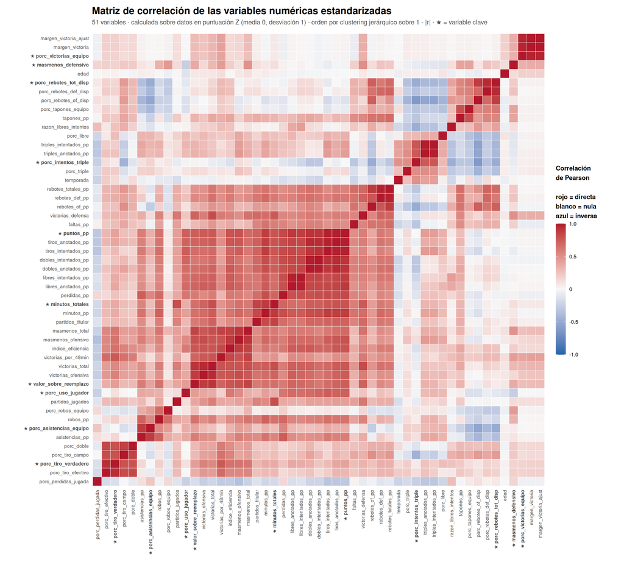

```r
# ============================================================
# MAPA DE CALOR ORDENADO POR CLUSTERING JERÁRQUICO
# ============================================================

distancias <- as.dist(1 - abs(matriz_correlacion))
orden_cluster <- hclust(distancias, method = "average")$order
niveles_orden <- colnames(matriz_correlacion)[orden_cluster]

cor_long <- as.data.frame(matriz_correlacion) %>%
  mutate(Variable1 = rownames(.)) %>%
  pivot_longer(
    cols = -Variable1,
    names_to = "Variable2",
    values_to = "Correlacion"
  ) %>%
  mutate(
    Variable1 = factor(Variable1, levels = niveles_orden),
    Variable2 = factor(Variable2, levels = niveles_orden),
    # Marcar las variables clave en las etiquetas de los ejes
    es_clave1 = Variable1 %in% vars_clave
  )

# Etiquetas: las variables clave se marcan con ★ y en negrita
etiquetas_eje <- ifelse(
  niveles_orden %in% vars_clave,
  paste0("★ ", niveles_orden),
  niveles_orden
)
names(etiquetas_eje) <- niveles_orden

caras_eje <- ifelse(niveles_orden %in% vars_clave, "bold", "plain")

ggplot(cor_long, aes(x = Variable1, y = Variable2, fill = Correlacion)) +

  geom_tile(color = "white", linewidth = 0.2) +

  scale_fill_gradient2(
    low = "#2166AC",
    mid = "#F7F7F7",
    high = "#B2182B",
    midpoint = 0,
    limits = c(-1, 1),
    breaks = c(-1, -0.5, 0, 0.5, 1),
    labels = c("-1.0", "-0.5", "0", "0.5", "1.0"),
    name = "Correlación\nde Pearson\n\nrojo = directa\nblanco = nula\nazul = inversa"
  ) +

  scale_x_discrete(labels = etiquetas_eje) +
  scale_y_discrete(labels = etiquetas_eje) +

  coord_fixed() +

  labs(
    title = "Matriz de correlación de las variables numéricas estandarizadas",
    subtitle = paste0(
      length(vars_numericas), " variables · calculada sobre datos en puntuación Z ",
      "(media 0, desviación 1) · orden por clustering jerárquico sobre 1 - |r| · ",
      "★ = variable clave"
    ),
    x = NULL, y = NULL
  ) +

  theme_minimal(base_size = 12) +

  theme(
    panel.grid = element_blank(),
    axis.text.x = element_text(angle = 90, hjust = 1, vjust = 0.5, size = 8.5,
                               face = caras_eje),
    axis.text.y = element_text(size = 8.5, face = caras_eje),
    plot.title = element_text(face = "bold", size = 17),
    plot.subtitle = element_text(size = 11, color = "grey30", margin = margin(b = 12)),
    legend.position = "right",
    legend.key.height = unit(1.6, "cm"),
    legend.title = element_text(size = 11, face = "bold", lineheight = 1.25,
                                margin = margin(b = 8)),
    legend.text = element_text(size = 9),
    plot.margin = margin(12, 12, 12, 12)
  )
```

**Cómo leer este mapa.** Los **bloques rojos contiguos a lo largo de la diagonal** son los grupos de variables que miden prácticamente lo mismo: se distinguen con claridad el bloque de **volumen ofensivo** (tiros anotados e intentados, puntos, tiros de 2), el de **métricas compuestas de valor** (Win Shares, BPM, VORP, PER), el de **rebote** (versiones por partido y normalizadas juntas), el del **triple** y el de **contexto de equipo** (margen de victoria, margen ajustado, porcentaje de victorias). Las zonas **azules** señalan las pocas relaciones inversas fuertes del dataset, y las **blancas** la ausencia de relación lineal.

El resultado justifica visualmente la selección de la sección *Selección de variables clave*: las 10 variables marcadas con ★ están **repartidas entre los distintos bloques**, una por bloque, en lugar de concentrarse en uno solo. Un panel formado por varias variables del mismo bloque rojo (por ejemplo, puntos, tiros anotados y tiros intentados a la vez) tendría tres columnas para medir una sola dimensión.

## 10.4 Detalle numérico: las 10 variables clave

Este segundo mapa de calor se limita al panel clave y **sí imprime el coeficiente en cada celda**, para poder leer valores exactos. Es la comprobación visual de que las 10 variables miden dimensiones distintas.

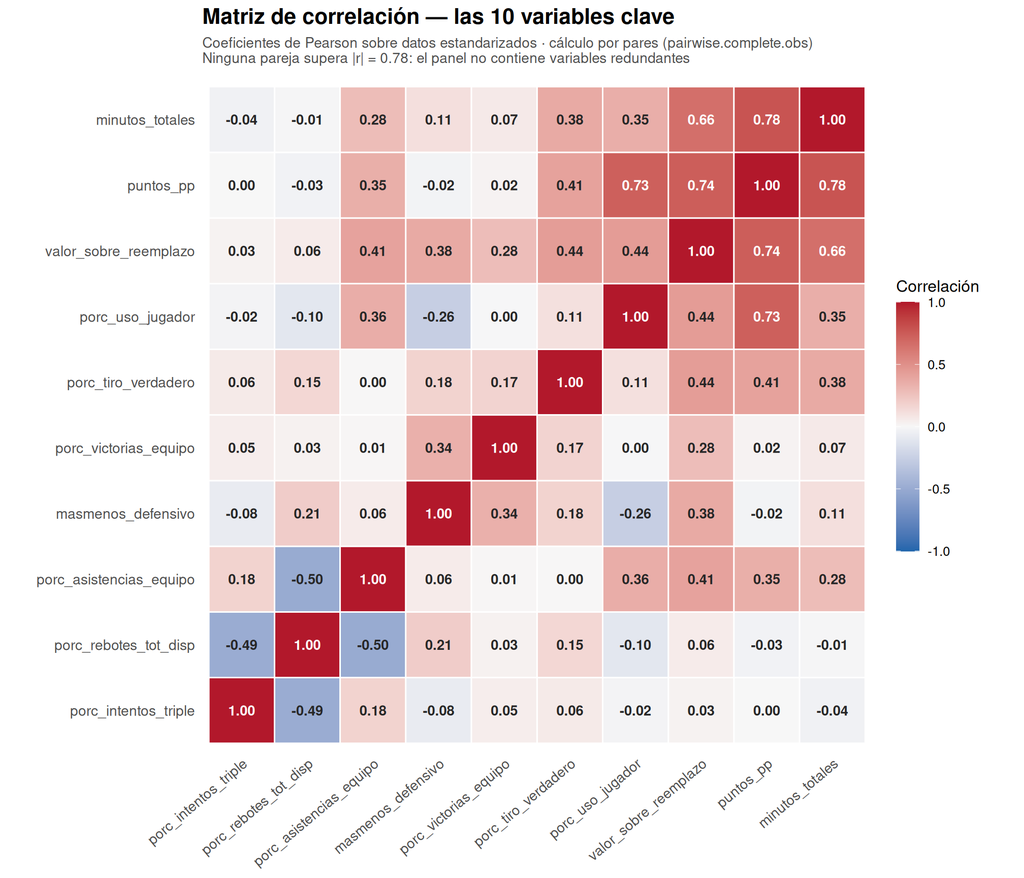

```r
matriz_clave <- cor(
  as.data.frame(datos_estandarizados) %>% select(all_of(vars_clave)),
  use = "pairwise.complete.obs"
)

orden_clave <- hclust(as.dist(1 - abs(matriz_clave)), method = "average")$order
niveles_clave <- rownames(matriz_clave)[orden_clave]

cor_clave_long <- as.data.frame(matriz_clave) %>%
  mutate(Variable1 = rownames(.)) %>%
  pivot_longer(cols = -Variable1, names_to = "Variable2", values_to = "Correlacion") %>%
  mutate(
    Variable1 = factor(Variable1, levels = niveles_clave),
    Variable2 = factor(Variable2, levels = niveles_clave)
  )

ggplot(cor_clave_long, aes(x = Variable1, y = Variable2, fill = Correlacion)) +
  geom_tile(color = "white", linewidth = 0.5) +
  geom_text(
    aes(
      label = ifelse(abs(Correlacion) < 0.005, "0.00", sprintf("%.2f", Correlacion)),
      color = abs(Correlacion) > 0.6
    ),
    size = 3.6, fontface = "bold", show.legend = FALSE
  ) +
  scale_color_manual(values = c(`TRUE` = "white", `FALSE` = "grey15")) +
  scale_fill_gradient2(
    low = "#2166AC", mid = "#F7F7F7", high = "#B2182B",
    midpoint = 0, limits = c(-1, 1),
    breaks = c(-1, -0.5, 0, 0.5, 1),
    name = "Correlación"
  ) +
  coord_fixed() +
  labs(
    title = "Matriz de correlación — las 10 variables clave",
    subtitle = paste0(
      "Coeficientes de Pearson sobre datos estandarizados · cálculo por pares ",
      "(pairwise.complete.obs)\nNinguna pareja supera |r| = ",
      round(max(abs(redundancia$r)), 2), ": el panel no contiene variables redundantes"
    ),
    x = NULL, y = NULL
  ) +
  theme_minimal(base_size = 12) +
  theme(
    panel.grid = element_blank(),
    axis.text.x = element_text(angle = 40, hjust = 1, size = 10.5),
    axis.text.y = element_text(size = 10.5),
    plot.title = element_text(face = "bold", size = 16),
    plot.subtitle = element_text(size = 10.5, color = "grey30", margin = margin(b = 10)),
    legend.key.height = unit(1.3, "cm")
  )
```

## 10.5 Pares de variables con mayor y menor correlación

```r
cor_pares_long <- as.data.frame(matriz_correlacion) %>%
  mutate(Variable1 = rownames(.)) %>%
  pivot_longer(cols = -Variable1, names_to = "Variable2", values_to = "Correlacion") %>%
  filter(Variable1 != Variable2) %>%
  mutate(
    par_id = map2_chr(Variable1, Variable2, ~ paste(sort(c(.x, .y)), collapse = " -- "))
  ) %>%
  distinct(par_id, .keep_all = TRUE) %>%
  select(Variable1, Variable2, Correlacion) %>%
  arrange(desc(abs(Correlacion)))

top15_cor <- head(cor_pares_long, 15)
bottom5_cor <- cor_pares_long %>% arrange(abs(Correlacion)) %>% head(5)

top15_cor %>%
  kable(
    digits = 4,
    col.names = c("Variable 1", "Variable 2", "Correlación (Pearson)"),
    caption = "Los 15 pares de variables con mayor correlación en valor absoluto"
  ) %>%
  kable_styling(bootstrap_options = c("striped", "hover", "condensed"), full_width = FALSE) %>%
  column_spec(1:2, monospace = TRUE)
```

Los 15 pares de variables con mayor correlación en valor absoluto

| Variable 1 | Variable 2 | Correlación (Pearson) |
| --- | --- | --- |
| margen_victoria | margen_victoria_ajust | 0.9970 |
| tiros_anotados_pp | puntos_pp | 0.9886 |
| triples_anotados_pp | triples_intentados_pp | 0.9870 |
| dobles_anotados_pp | dobles_intentados_pp | 0.9865 |
| libres_anotados_pp | libres_intentados_pp | 0.9826 |
| tiros_intentados_pp | puntos_pp | 0.9811 |
| tiros_anotados_pp | tiros_intentados_pp | 0.9810 |
| rebotes_def_pp | rebotes_totales_pp | 0.9761 |
| margen_victoria | porc_victorias_equipo | 0.9685 |
| margen_victoria_ajust | porc_victorias_equipo | 0.9657 |
| tiros_anotados_pp | dobles_anotados_pp | 0.9536 |
| porc_rebotes_def_disp | porc_rebotes_tot_disp | 0.9498 |
| victorias_ofensiva | victorias_total | 0.9472 |
| tiros_anotados_pp | dobles_intentados_pp | 0.9458 |
| porc_tiro_efectivo | porc_tiro_verdadero | 0.9366 |

```r
bottom5_cor %>%
  kable(
    digits = 4,
    col.names = c("Variable 1", "Variable 2", "Correlación (Pearson)"),
    caption = "Los 5 pares con menor correlación en valor absoluto (más cercanos a 0)"
  ) %>%
  kable_styling(bootstrap_options = c("striped", "hover", "condensed"), full_width = FALSE) %>%
  column_spec(1:2, monospace = TRUE)
```

Los 5 pares con menor correlación en valor absoluto (más cercanos a 0)

| Variable 1 | Variable 2 | Correlación (Pearson) |
| --- | --- | --- |
| temporada | porc_victorias_equipo | 0.0001 |
| tiros_anotados_pp | porc_rebotes_tot_disp | -0.0001 |
| temporada | margen_victoria | -0.0003 |
| temporada | margen_victoria_ajust | -0.0005 |
| porc_rebotes_of_disp | victorias_ofensiva | 0.0007 |

```r
diff_ws <- max(abs(df$victorias_total - (df$victorias_ofensiva + df$victorias_defensa)), na.rm = TRUE)
diff_bpm <- max(abs(df$masmenos_total - (df$masmenos_ofensivo + df$masmenos_defensivo)), na.rm = TRUE)
diff_trb <- max(abs(df$rebotes_totales_pp - (df$rebotes_of_pp + df$rebotes_def_pp)), na.rm = TRUE)
diff_fga <- max(abs(df$tiros_intentados_pp - (df$dobles_intentados_pp + df$triples_intentados_pp)), na.rm = TRUE)

cor_ptsfga <- cor(df$puntos_pp, df$tiros_intentados_pp, use = "pairwise.complete.obs")
cor_winmov <- cor(df$porc_victorias_equipo, df$margen_victoria, use = "pairwise.complete.obs")
cor_movajust <- cor(df$margen_victoria, df$margen_victoria_ajust, use = "pairwise.complete.obs")
```

**Interpretación académica detallada.**

La matriz muestra **relaciones fuertes, reales y con causas identificables**. Lo esencial es distinguir **cuatro tipos de relación** que aparecen mezclados en la tabla de pares más fuertes, porque solo uno de ellos constituye un hallazgo:

**1. Identidades matemáticas (no son descubrimientos empíricos).** Varias de las correlaciones más altas no reflejan una relación estadística descubierta en los datos, sino una **relación de definición**, donde una variable es por construcción la suma de otras dos:

- `victorias_total` = `victorias_ofensiva` + `victorias_defensa` — el desvío máximo observado entre ambos lados de la igualdad es de apenas 0.1 (redondeo de publicación).
- `masmenos_total` = `masmenos_ofensivo` + `masmenos_defensivo` (desvío máximo 0.1).
- `rebotes_totales_pp` = `rebotes_of_pp` + `rebotes_def_pp` (desvío máximo 0.1).
- `tiros_intentados_pp` = `dobles_intentados_pp` + `triples_intentados_pp` (desvío máximo 0.1).

Que estos pares aparezcan con correlación cercana a 1 **no aporta información nueva sobre el comportamiento de los jugadores**: es esperable por álgebra, no por baloncesto. Interpretar este tipo de relación como un hallazgo es un error frecuente en analítica deportiva. Nótese que por esta razón el panel clave incluye `masmenos_defensivo` pero **no** `masmenos_total`: usar ambas sería contar la defensa dos veces.

**2. Relaciones mecánicas de volumen (fuertes, pero no idénticas).** El par más correlacionado de todo el dataset es margen_victoria – margen_victoria_ajust (**r = 0.997**). Relaciones como `puntos_pp` – `tiros_anotados_pp`, `puntos_pp` – `tiros_intentados_pp` (r = 0.981) o `minutos_totales` – `minutos_pp` son muy fuertes porque comparten un componente común de **volumen de uso**: quien intenta más tiros casi siempre anota más puntos, y quien acumula más minutos totales casi siempre promedia más minutos por partido. No son identidades algebraicas exactas (median también la eficiencia y el número de partidos, respectivamente), pero sí relaciones altamente mecánicas y esperables. Son la razón por la que este documento prefiere métricas **normalizadas por posesión** en el panel clave.

**3. Relaciones de medición redundante.** Un tercer grupo, intermedio entre los dos anteriores, son pares de variables que **miden el mismo concepto con fórmulas distintas**: `porc_tiro_efectivo` – `porc_tiro_verdadero` (r = 0.937), ambas medidas de eficiencia de tiro que difieren solo en el tratamiento de los tiros libres, o `margen_victoria` – `margen_victoria_ajust` (r = 0.997), donde la segunda es la primera corregida por fuerza de calendario. La corrección existe y es metodológicamente correcta, pero **empíricamente cambia tan poco** que a lo largo de 41 temporadas las durezas de calendario se compensan casi por completo. En estos casos, incluir ambas variables en un modelo no añade información: añade multicolinealidad.

**4. Relaciones genuinamente empíricas (el hallazgo sustantivo).** La relación entre `porc_victorias_equipo` y `margen_victoria` (r = 0.968) **sí es un hallazgo del mundo real**, no una identidad de fórmula: el margen de puntos promedio de un equipo predice casi perfectamente su porcentaje de victorias. Es una versión de la conocida *expectativa pitagórica* de la analítica deportiva (popularizada por Bill James en béisbol): los equipos que dominan el marcador de forma consistente ganan en proporción muy predecible, porque a lo largo de miles de posesiones la suerte en los partidos ajustados se promedia. Que la relación emerja con esta fuerza en un dataset a nivel de **jugador** (donde ambas variables son en realidad atributos del equipo, repetidos en cada fila de su plantilla) confirma su robustez.

Igualmente empírica —y más interesante para la evaluación individual— es la correlación **negativa** entre `porc_rebotes_tot_disp` y `porc_asistencias_equipo` (r = -0.504): nada en las fórmulas obliga a que un buen reboteador asista poco. Lo que se está midiendo es la **especialización posicional real** del baloncesto.

**Pares más débiles.** En el otro extremo, el par con menor correlación absoluta de la matriz es temporada – porc_victorias_equipo (**r = 0.0001**), prácticamente nula. Es revelador que **tres de los cinco pares más débiles involucren a `temporada`** con variables de contexto de equipo (`porc_victorias_equipo`, `margen_victoria`, `margen_victoria_ajust`): el nivel competitivo medio de la liga es, por construcción, **constante en el tiempo** —siempre se reparten los mismos partidos entre los mismos equipos—, así que no existe tendencia temporal que correlacionar. Que la matriz distinga con nitidez entre pares fuertemente relacionados y pares genuinamente independientes confirma que **discrimina estructura real**, no ruido.

**Implicación práctica.** Antes de usar esta matriz para seleccionar variables en un modelo predictivo (por ejemplo, para predecir `valor_sobre_reemplazo`) es indispensable:

1. **Excluir las identidades algebraicas** del punto 1 (usar las componentes o el total, nunca ambos).
2. **Elegir una sola variable por bloque de color** del mapa de calor general — que es exactamente el procedimiento seguido para construir el panel de 10 variables clave.
3. **Controlar por `minutos_totales`** siempre que se usen estadísticas “por partido”, o preferir directamente las versiones normalizadas por posesión.
4. **Recordar que `porc_victorias_equipo`, `margen_victoria` y `margen_victoria_ajust` son atributos del equipo**, no del jugador: correlacionan con el rendimiento individual en ambas direcciones causales.

# 11 Conclusiones generales

- El dataset depurado contiene **14,078 registros temporada-jugador y 54 variables** de la NBA entre 1982 y 2022, de las cuales 51 son numéricas, 2 categóricas (`posicion`, `equipo`), 1 (`jugador`) es identificador y **ninguna es booleana**.
- **La depuración fue determinante para la calidad del análisis.** El filtro `minutos_totales >= 100` no solo eliminó ruido: dejó las métricas de tasa en rangos plausibles (el PER pasó a -4.8 – 32.8, y `porc_tiro_verdadero` dejó de superar el imposible 1.0), **completó todas las métricas avanzadas** (0 `NA`) y redujo los valores faltantes al 0.21% de las celdas. Eliminar las filas `"TOT"` y consolidar `posicion` en 5 categorías balanceadas suprimió además todos los casos especiales que obligaban a excepciones en el código.
- **Las 10 variables clave cubren dimensiones genuinamente distintas.** La verificación es cuantitativa: su correlación absoluta mediana es 0.174 y **ninguna pareja supera |r| = 0.8**, frente a los pares del dataset completo que llegan a r = 0.997. Valor global (VORP), producción (puntos), oportunidad (minutos), eficiencia (TS%), rol (USG%), interior (TRB%), creación (AST%), estilo (% de intentos de triple), defensa (DBPM) y contexto (% de victorias del equipo) forman un panel interpretable que resume 51 variables numéricas.
- **La asimetría es la regla, no la excepción, en las variables de valor.** VORP (asimetría 2.17) y AST% (1.24) muestran que tanto el valor como la creación de juego están **concentrados en una minoría de jugadores**: la mitad del dataset aporta un VORP prácticamente igual al de un jugador de reemplazo. En cambio, las variables ancladas por la estructura de la competición (minutos, USG%, DBPM, % de victorias) son casi simétricas.
- **La estandarización deja el terreno preparado para el análisis multivariado.** La matriz `datos_estandarizados` (media 0, desviación 1, verificado) es el insumo directo de PCA y clustering, técnicas que **sí** dependen de la escala. Sobre ella, la matriz de correlación coincide con la de covarianzas y cada celda se lee en desviaciones estándar. Como la correlación de Pearson es invariante a transformaciones lineales, el resultado numérico es idéntico al de los datos originales (desvío máximo 1.11e-16): lo que aporta el paso es **comparabilidad y verificabilidad**, no un cambio en los coeficientes.
- **Hay que distinguir cuatro tipos de correlación** antes de interpretar: identidades algebraicas (`victorias_total = victorias_ofensiva + victorias_defensa`), relaciones mecánicas de volumen (puntos vs. intentos de tiro), mediciones redundantes del mismo concepto (eFG% vs. TS%, margen vs. margen ajustado) y hallazgos genuinamente empíricos —el margen de victoria prediciendo el porcentaje de victorias (r = 0.968, *expectativa pitagórica*) y la oposición entre rebote y creación de juego (r = -0.504, especialización posicional).
- **Advertencia temporal.** `porc_intentos_triple` correlaciona a r = 0.5 con `temporada`: las distribuciones agregadas de este documento **mezclan 41 temporadas con estilos de juego muy distintos**. Cualquier modelo sobre variables de tiro debería incluir `temporada` como control o segmentar por era.
- **Siguientes pasos naturales:** (1) PCA sobre `datos_estandarizados` excluyendo las identidades algebraicas, para cuantificar cuántas dimensiones independientes tiene realmente el rendimiento de un jugador;
  2. clustering para identificar **arquetipos** de jugador sobre el panel de 10 variables clave; (3) un modelo de `valor_sobre_reemplazo` usando solo predictores no redundantes; y (4) un análisis explícito de **evolución temporal** que aproveche las 41 temporadas disponibles.

# 12 Análisis bivariado

El análisis univariado permitió caracterizar cada variable por separado y dejó tres resultados de partida: un panel de **10 variables clave**, cada una representando una dimensión distinta del rendimiento sin que ninguna pareja entre ellas supere una correlación absoluta de 0.8; una **matriz de correlación completa**, que distinguió identidades algebraicas, relaciones mecánicas de volumen, mediciones redundantes y hallazgos genuinamente empíricos; y la advertencia de que variables como `porc_intentos_triple` o `edad` mezclan información que solo se interpreta correctamente al examinar subgrupos o la evolución temporal, y no un único coeficiente.

## 12.1 Relaciones analizadas

```r
relaciones <- tribble(
  ~Relacion, ~Variables, ~Tecnica, ~Pregunta,
  "1. Uso ofensivo vs. eficiencia de tiro", "porc_uso_jugador vs. porc_tiro_verdadero", "Dispersión + recta de ajuste + cuadrantes", "¿Tirar más cuesta eficiencia, o hay estrellas que hacen ambas cosas?",
  "2. Rendimiento vs. edad", "edad vs. indice_eficiencia, porc_tiro_verdadero, minutos_pp", "Boxplots por grupo de edad", "¿A qué edad rinde más un jugador promedio, y por qué un coeficiente sería engañoso?",
  "3. Asistencias vs. pérdidas, por posición", "asistencias_pp vs. perdidas_pp, agrupado por posicion", "Boxplots por posición + correlación dentro de cada grupo", "¿El manejo de balón cuesta pérdidas dentro del mismo rol, o solo entre roles distintos?",
  "4. % de intentos de triple vs. temporada", "porc_intentos_triple vs. temporada", "Boxplots por era (grupos de temporadas)", "¿Cuándo y qué tan rápido cambió el estilo de juego de la NBA?",
  "5. Rebote vs. creación de juego", "porc_rebotes_tot_disp vs. porc_asistencias_equipo", "Dispersión coloreada por posición", "¿Rebotear y asistir son roles opuestos, y quién rompe esa regla?",
  "6. Protagonismo vs. producción", "porc_uso_jugador vs. puntos_pp", "Dispersión + recta de ajuste + cuadrante bajo-alto", "¿Se puede anotar mucho sin ser el protagonista ofensivo del equipo?",
  "7. Oportunidad vs. valor total", "minutos_totales vs. valor_sobre_reemplazo", "Boxplots por decil de minutos", "¿El valor crece proporcional a los minutos, o se acelera?",
  "8. Manejo de balón vs. pérdidas normalizadas", "porc_uso_jugador vs. porc_perdidas_jugada", "Dispersión + recta de ajuste", "¿Más protagonismo implica más riesgo de pérdida por jugada?",
  "9. Contexto de equipo vs. impacto defensivo", "porc_victorias_equipo vs. masmenos_defensivo", "Dispersión + recta de ajuste + cuadrante", "¿Los buenos defensores solo aparecen en equipos ganadores?",
  "10. Experiencia vs. eficiencia, por edad de entrada", "experiencia (derivada) vs. indice_eficiencia, por edad_entrada (derivada)", "Boxplots agrupados por bloque de experiencia y edad de entrada", "¿Un novato que entra joven rinde distinto, a igual experiencia, que uno que entra mayor?",
  "11. Anotación vs. creación de juego, por posición", "puntos_pp vs. asistencias_pp, coloreado por posicion", "Dispersión coloreada por posición + recta de ajuste global", "¿Anotar mucho implica asistir poco, o ese supuesto compromiso no se cumple?"
)

relaciones %>%
  kable(
    col.names = c("Relación", "Variables", "Técnica", "Pregunta que responde"),
    caption = "Las 11 relaciones bivariadas seleccionadas para esta sección"
  ) %>%
  kable_styling(
    bootstrap_options = c("striped", "hover", "condensed"),
    font_size = 12
  ) %>%
  column_spec(1, bold = TRUE, width = "20%") %>%
  column_spec(2, monospace = TRUE, width = "22%")
```

Las 11 relaciones bivariadas seleccionadas para esta sección

Relación

Variables

Técnica

Pregunta que responde

1. Uso ofensivo vs. eficiencia de tiro

porc_uso_jugador vs. porc_tiro_verdadero

Dispersión + recta de ajuste + cuadrantes

¿Tirar más cuesta eficiencia, o hay estrellas que hacen ambas cosas?

2. Rendimiento vs. edad

edad vs. indice_eficiencia, porc_tiro_verdadero, minutos_pp

Boxplots por grupo de edad

¿A qué edad rinde más un jugador promedio, y por qué un coeficiente sería engañoso?

3. Asistencias vs. pérdidas, por posición

asistencias_pp vs. perdidas_pp, agrupado por posicion

Boxplots por posición + correlación dentro de cada grupo

¿El manejo de balón cuesta pérdidas dentro del mismo rol, o solo entre roles distintos?

4. % de intentos de triple vs. temporada

porc_intentos_triple vs. temporada

Boxplots por era (grupos de temporadas)

¿Cuándo y qué tan rápido cambió el estilo de juego de la NBA?

5. Rebote vs. creación de juego

porc_rebotes_tot_disp vs. porc_asistencias_equipo

Dispersión coloreada por posición

¿Rebotear y asistir son roles opuestos, y quién rompe esa regla?

6. Protagonismo vs. producción

porc_uso_jugador vs. puntos_pp

Dispersión + recta de ajuste + cuadrante bajo-alto

¿Se puede anotar mucho sin ser el protagonista ofensivo del equipo?

7. Oportunidad vs. valor total

minutos_totales vs. valor_sobre_reemplazo

Boxplots por decil de minutos

¿El valor crece proporcional a los minutos, o se acelera?

8. Manejo de balón vs. pérdidas normalizadas

porc_uso_jugador vs. porc_perdidas_jugada

Dispersión + recta de ajuste

¿Más protagonismo implica más riesgo de pérdida por jugada?

9. Contexto de equipo vs. impacto defensivo

porc_victorias_equipo vs. masmenos_defensivo

Dispersión + recta de ajuste + cuadrante

¿Los buenos defensores solo aparecen en equipos ganadores?

10. Experiencia vs. eficiencia, por edad de entrada

experiencia (derivada) vs. indice_eficiencia, por edad_entrada (derivada)

Boxplots agrupados por bloque de experiencia y edad de entrada

¿Un novato que entra joven rinde distinto, a igual experiencia, que uno que entra mayor?

11. Anotación vs. creación de juego, por posición

puntos_pp vs. asistencias_pp, coloreado por posicion

Dispersión coloreada por posición + recta de ajuste global

¿Anotar mucho implica asistir poco, o ese supuesto compromiso no se cumple?

De las propuestas iniciales se descartaron cuatro por falta de datos en `nbaFINAL.csv` (estatura, salario, indicador de fase playoffs/temporada regular e indicador de franquicia campeona): ninguna de esas columnas existe en el archivo, y construirlas exigiría fusionar fuentes externas fuera del alcance de este dataset.

## 12.2 1. Uso ofensivo (USG%) vs. eficiencia de tiro (TS%)

La variable `porc_uso_jugador`, conocida en la analítica de baloncesto como Porcentaje de Uso (*Usage Percentage*, USG%), estima qué proporción de las jugadas del equipo termina siendo decidida por ese jugador —con un tiro, una falta recibida que lo envía a la línea de libres, o una pérdida— mientras está en cancha. La variable `porc_tiro_verdadero`, o Porcentaje de Tiro Verdadero (*True Shooting Percentage*, TS%), mide qué tan eficiente es anotando, combinando en un solo valor los tiros de dos puntos, los triples y los tiros libres. La pregunta que se examina no es cuál jugador anota más, sino si tomar un mayor volumen de tiro implica necesariamente una pérdida de eficiencia.

```r
r_uso_ts <- cor(df$porc_uso_jugador, df$porc_tiro_verdadero, use = "pairwise.complete.obs")
med_usg  <- median(df$porc_uso_jugador, na.rm = TRUE)
med_ts   <- median(df$porc_tiro_verdadero, na.rm = TRUE)
```

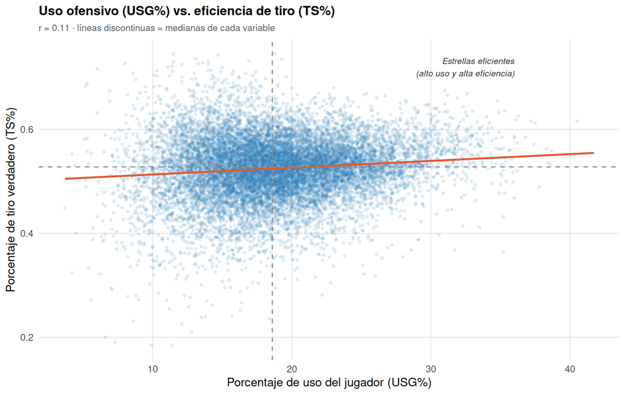

```r
ggplot(df, aes(x = porc_uso_jugador, y = porc_tiro_verdadero)) +
  geom_point(alpha = 0.12, color = col_punto, size = 1, na.rm = TRUE) +
  geom_smooth(method = "lm", se = FALSE, color = col_ajuste, linewidth = 1, na.rm = TRUE) +
  geom_hline(yintercept = med_ts, linetype = "dashed", color = "grey55") +
  geom_vline(xintercept = med_usg, linetype = "dashed", color = "grey55") +
  annotate("text", x = 36, y = 0.72,
           label = "Estrellas eficientes\n(alto uso y alta eficiencia)",
           hjust = 1, size = 3.3, fontface = "italic", color = "grey20") +
  labs(
    title = "Uso ofensivo (USG%) vs. eficiencia de tiro (TS%)",
    subtitle = paste0("r = ", round(r_uso_ts, 3),
                       " · líneas discontinuas = medianas de cada variable"),
    x = "Porcentaje de uso del jugador (USG%)",
    y = "Porcentaje de tiro verdadero (TS%)"
  ) +
  tema_biv
```

```r
df %>%
  filter(porc_uso_jugador > med_usg, porc_tiro_verdadero > med_ts) %>%
  slice_max(valor_sobre_reemplazo, n = 5) %>%
  select(jugador, temporada, porc_uso_jugador, porc_tiro_verdadero, valor_sobre_reemplazo) %>%
  kable(
    digits = c(0, 0, 1, 3, 1),
    col.names = c("Jugador", "Temporada", "USG% (uso ofensivo)", "TS% (eficiencia de tiro)", "VORP (valor total aportado)"),
    caption = "Rompen el patrón: alto uso Y alta eficiencia a la vez"
  ) %>%
  kable_styling(bootstrap_options = c("striped", "condensed"), full_width = FALSE)
```

Rompen el patrón: alto uso Y alta eficiencia a la vez

| Jugador | Temporada | USG% (uso ofensivo) | TS% (eficiencia de tiro) | VORP (valor total aportado) |
| --- | --- | --- | --- | --- |
| Michael Jordan | 1988 | 34.1 | 0.603 | 12.5 |
| LeBron James | 2009 | 33.8 | 0.591 | 11.8 |
| Michael Jordan | 1989 | 32.1 | 0.614 | 11.4 |
| David Robinson | 1994 | 32.0 | 0.577 | 11.4 |
| Michael Jordan | 1991 | 32.9 | 0.605 | 10.8 |

```r
df %>%
  filter(
    porc_uso_jugador > quantile(porc_uso_jugador, 0.85, na.rm = TRUE),
    porc_tiro_verdadero < quantile(porc_tiro_verdadero, 0.25, na.rm = TRUE)
  ) %>%
  slice_max(porc_uso_jugador, n = 5) %>%
  select(jugador, temporada, porc_uso_jugador, porc_tiro_verdadero, puntos_pp) %>%
  kable(
    digits = c(0, 0, 1, 3, 1),
    col.names = c("Jugador", "Temporada", "USG% (uso ofensivo)", "TS% (eficiencia de tiro)", "Puntos por partido"),
    caption = "Alto uso con baja eficiencia: anotan por volumen, no por conversión"
  ) %>%
  kable_styling(bootstrap_options = c("striped", "condensed"), full_width = FALSE)
```

Alto uso con baja eficiencia: anotan por volumen, no por conversión

| Jugador | Temporada | USG% (uso ofensivo) | TS% (eficiencia de tiro) | Puntos por partido |
| --- | --- | --- | --- | --- |
| Allen Iverson | 2002 | 37.8 | 0.489 | 31.4 |
| Michael Jordan | 2002 | 36.0 | 0.468 | 22.9 |
| Allen Iverson | 2004 | 35.3 | 0.478 | 26.4 |
| Oliver Robinson | 1983 | 35.2 | 0.432 | 2.9 |
| John Schweitz | 1985 | 35.2 | 0.364 | 3.0 |

**Interpretación:** la correlación entre ambas variables es prácticamente nula (r = 0.11), lo que es consistente con lo señalado en el análisis univariado, donde `porc_tiro_verdadero` se identificó como una variable que aporta información independiente del uso (r = 0.11 con `porc_uso_jugador`). La nube de puntos no tiene forma de elipse inclinada, sino una mancha ancha sin pendiente definida, lo que confirma que, en promedio, usar más el balón no implica ni mejor ni peor eficiencia. El promedio, sin embargo, no es lo más informativo de esta relación: son los extremos los que distinguen tipos de jugador. El cuadrante superior derecho —USG% y TS% simultáneamente altos— lo ocupan Michael Jordan, LeBron James y David Robinson en algunas de sus mejores temporadas, mostrando que llevar el peso ofensivo del equipo y anotar con eficiencia de élite al mismo tiempo es la firma estadística de una superestrella. En el extremo opuesto, jugadores como Allen Iverson o un Michael Jordan de 38 años en los Washington Wizards mantienen un USG% alto sin la eficiencia que lo acompañaba en sus mejores años, lo que indica que siguen concentrando el balón por rol o por falta de alternativas en el equipo, más que por su rendimiento actual. Para un cuerpo técnico, distinguir entre ambos grupos equivale a decidir a quién conviene seguir dándole el balón y a quién ya no.

## 12.3 2. Rendimiento vs. edad, como curva y no como correlación

Esta relación examina la edad del jugador (`edad`) frente a tres indicadores de rendimiento: el Índice de Eficiencia del Jugador o PER (`indice_eficiencia`), el Porcentaje de Tiro Verdadero (`porc_tiro_verdadero`, TS%) y los minutos jugados por partido (`minutos_pp`). El PER resume, por cada minuto en cancha, la producción positiva de un jugador (puntos, rebotes, asistencias, robos, tapones) menos la negativa (tiros fallados, pérdidas, faltas), calibrado de forma que el promedio de la liga en cualquier temporada sea igual a 15; a diferencia de TS% y de los minutos, el PER no formó parte del panel de variables clave del análisis univariado, por lo que se introduce en esta sección. Ninguna de las tres métricas mantiene una relación lineal con la edad: cada una aumenta durante la juventud del jugador, alcanza un máximo y decae después. Reportar solo un coeficiente de correlación describiría esta relación de forma incompleta, porque un valor cercano a cero puede ocultar una curva real en lugar de la ausencia de relación.

```r
r_edad_per <- cor(df$edad, df$indice_eficiencia, use = "pairwise.complete.obs")

resumen_edad <- df %>%
  group_by(edad) %>%
  summarise(
    PER = mean(indice_eficiencia, na.rm = TRUE),
    TS = mean(porc_tiro_verdadero, na.rm = TRUE),
    Minutos = mean(minutos_pp, na.rm = TRUE),
    n = n(),
    .groups = "drop"
  )

edad_pico_per <- resumen_edad$edad[which.max(resumen_edad$PER)]

# Agrupar la edad en rangos para poder resumir la curva con boxplots
df <- df %>%
  mutate(
    grupo_edad = cut(
      edad,
      breaks = c(17, 21, 24, 27, 30, 33, 50),
      labels = c("18-21", "22-24", "25-27", "28-30", "31-33", "34+"),
      right = TRUE
    )
  )
```

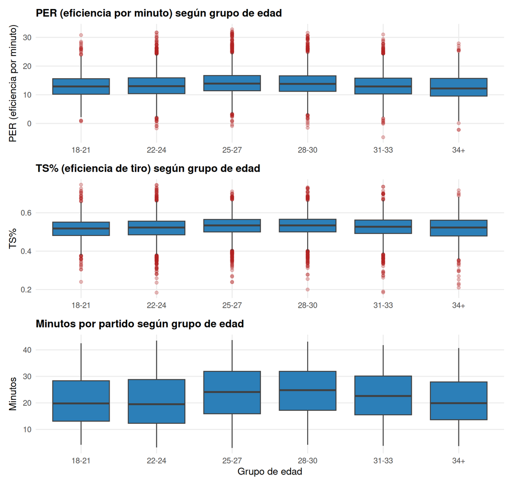

```r
p_per <- ggplot(df, aes(x = grupo_edad, y = indice_eficiencia)) +
  geom_boxplot(fill = col_punto, color = "grey25", outlier.color = col_outlier,
               outlier.alpha = 0.3, na.rm = TRUE) +
  labs(title = "PER (eficiencia por minuto) según grupo de edad", x = NULL, y = "PER (eficiencia por minuto)") +
  tema_biv

p_ts <- ggplot(df, aes(x = grupo_edad, y = porc_tiro_verdadero)) +
  geom_boxplot(fill = col_punto, color = "grey25", outlier.color = col_outlier,
               outlier.alpha = 0.3, na.rm = TRUE) +
  labs(title = "TS% (eficiencia de tiro) según grupo de edad", x = NULL, y = "TS%") +
  tema_biv

p_min <- ggplot(df, aes(x = grupo_edad, y = minutos_pp)) +
  geom_boxplot(fill = col_punto, color = "grey25", outlier.color = col_outlier,
               outlier.alpha = 0.3, na.rm = TRUE) +
  labs(title = "Minutos por partido según grupo de edad", x = "Grupo de edad", y = "Minutos") +
  tema_biv

p_per / p_ts / p_min
```

```r
resumen_edad %>%
  filter(edad >= 19, edad <= 38) %>%
  select(edad, PER, TS, Minutos, n) %>%
  kable(
    digits = c(0, 1, 3, 1, 0),
    col.names = c("Edad", "PER promedio (eficiencia por minuto)", "TS% promedio (eficiencia de tiro)", "Minutos/partido promedio", "Cantidad de temporadas-jugador (n)"),
    caption = "Promedio de tres métricas de rendimiento, por edad"
  ) %>%
  kable_styling(bootstrap_options = c("striped", "condensed"), full_width = FALSE) %>%
  scroll_box(height = "300px")
```

Promedio de tres métricas de rendimiento, por edad

| Edad | PER promedio (eficiencia por minuto) | TS% promedio (eficiencia de tiro) | Minutos/partido promedio | Cantidad de temporadas-jugador (n) |
| --- | --- | --- | --- | --- |
| 19 | 12.1 | 0.506 | 19.9 | 130 |
| 20 | 12.8 | 0.514 | 20.3 | 348 |
| 21 | 13.5 | 0.521 | 21.3 | 555 |
| 22 | 13.1 | 0.516 | 19.9 | 1092 |
| 23 | 13.1 | 0.517 | 20.3 | 1441 |
| 24 | 13.5 | 0.524 | 21.6 | 1444 |
| 25 | 14.1 | 0.530 | 23.1 | 1316 |
| 26 | 14.3 | 0.531 | 23.8 | 1201 |
| 27 | 14.3 | 0.532 | 24.5 | 1116 |
| 28 | 14.3 | 0.534 | 24.7 | 1004 |
| 29 | 14.0 | 0.533 | 24.1 | 936 |
| 30 | 13.8 | 0.529 | 24.0 | 818 |
| 31 | 13.3 | 0.523 | 23.1 | 690 |
| 32 | 13.4 | 0.528 | 22.5 | 562 |
| 33 | 13.0 | 0.520 | 22.1 | 452 |
| 34 | 12.8 | 0.521 | 21.6 | 326 |
| 35 | 13.0 | 0.523 | 21.5 | 233 |
| 36 | 12.9 | 0.527 | 20.8 | 170 |
| 37 | 12.4 | 0.509 | 19.3 | 103 |
| 38 | 12.0 | 0.493 | 18.0 | 68 |

**Interpretación:** el coeficiente de correlación lineal entre `edad` e `indice_eficiencia` es r = -0.006, un valor esencialmente nulo. Sin embargo, los boxplots agrupados por rango de edad muestran que la distribución del PER no es constante: asciende del grupo 18-21 al grupo 25-27, donde se ubica el máximo (con el grupo 28-30 muy cercano), y desciende de forma sostenida hasta el grupo de 34 años o más. El mismo patrón de ascenso, pico y descenso aparece en TS% y en los minutos por partido. La correlación lineal no detecta esta forma porque mide asociación en una sola dirección: como la primera mitad de la relación es creciente y la segunda decreciente, ambas tendencias se cancelan en el coeficiente agregado, y solo se hacen visibles al segmentar por grupos de edad. Esta curva corresponde al ciclo de desarrollo físico y declive atlético típico de un deportista profesional, y tiene implicaciones directas para la gestión de un equipo: explica por qué los contratos de mayor cuantía en la NBA se concentran en jugadores de 24 a 29 años —el rango de mejor rendimiento esperado— y por qué extender un contrato largo a un jugador de 33 años implica, en términos estadísticos, apostar contra la tendencia más consistente de todo el conjunto de datos. De igual forma, dado que el PER promedio todavía está en ascenso antes de los 22 años, evaluar a un jugador joven únicamente por su producción en sus primeras temporadas subestima de forma sistemática su nivel potencial.

## 12.4 3. Asistencias vs. pérdidas de balón, controlando por posición

En esta relación se examinan las asistencias por partido (`asistencias_pp`) y las pérdidas de balón por partido (`perdidas_pp`). Una asistencia es el pase que habilita directamente la canasta de un compañero; una pérdida de balón es cualquier jugada en la que el equipo pierde la posesión sin llegar a lanzar (una intercepción, un balón que se le escapa de las manos al jugador, entre otras causas). El jugador que ocupa la posición de base (PG) es, por la naturaleza de su rol, quien más tiempo mantiene el balón en las manos, por lo que es esperable que registre tanto más asistencias como más pérdidas que el resto de posiciones. Comparar la razón entre ambas variables sin distinguir la posición del jugador repetiría el error de comparar grupos heterogéneos sin controlar la variable que los diferencia: en este caso, el rol que cada jugador ocupa en la cancha.

```r
tabla_asttov <- df %>%
  group_by(posicion) %>%
  summarise(
    asistencias_media = mean(asistencias_pp, na.rm = TRUE),
    perdidas_media = mean(perdidas_pp, na.rm = TRUE),
    razon_ast_tov = median(asistencias_pp / perdidas_pp, na.rm = TRUE),
    .groups = "drop"
  ) %>%
  arrange(razon_ast_tov)

orden_pos_ast <- tabla_asttov$posicion

# Correlación asistencias-pérdidas calculada por separado dentro de cada
# posición, para confirmar la relación de control sin necesitar un gráfico
# facetado.
cor_por_posicion <- df %>%
  group_by(posicion) %>%
  summarise(
    r_dentro_del_grupo = cor(asistencias_pp, perdidas_pp, use = "pairwise.complete.obs"),
    .groups = "drop"
  ) %>%
  arrange(match(posicion, orden_pos_ast))
```

```r
tabla_asttov %>%
  kable(
    digits = c(0, 2, 2, 2),
    col.names = c("Posición", "Asistencias/partido", "Pérdidas de balón/partido", "Asistencias por cada pérdida (razón AST/TOV, mediana)"),
    caption = "Asistencias, pérdidas y su razón, por posición (ordenado de menor a mayor razón)"
  ) %>%
  kable_styling(bootstrap_options = c("striped", "condensed"), full_width = FALSE)
```

Asistencias, pérdidas y su razón, por posición (ordenado de menor a mayor razón)

| Posición | Asistencias/partido | Pérdidas de balón/partido | Asistencias por cada pérdida (razón AST/TOV, mediana) |
| --- | --- | --- | --- |
| C | 1.05 | 1.21 | 0.75 |
| PF | 1.34 | 1.27 | 1.00 |
| SF | 1.77 | 1.31 | 1.29 |
| SG | 2.28 | 1.36 | 1.62 |
| PG | 4.32 | 1.72 | 2.44 |

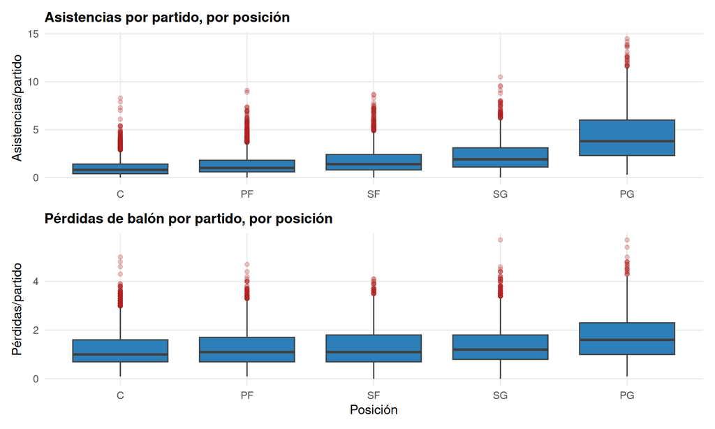

```r
p_ast <- ggplot(df, aes(x = factor(posicion, levels = orden_pos_ast), y = asistencias_pp)) +
  geom_boxplot(fill = col_punto, color = "grey25", outlier.color = col_outlier,
               outlier.alpha = 0.25, na.rm = TRUE) +
  labs(title = "Asistencias por partido, por posición", x = NULL, y = "Asistencias/partido") +
  tema_biv

p_tov <- ggplot(df, aes(x = factor(posicion, levels = orden_pos_ast), y = perdidas_pp)) +
  geom_boxplot(fill = col_punto, color = "grey25", outlier.color = col_outlier,
               outlier.alpha = 0.25, na.rm = TRUE) +
  labs(title = "Pérdidas de balón por partido, por posición", x = "Posición", y = "Pérdidas/partido") +
  tema_biv

p_ast / p_tov
```

```r
cor_por_posicion %>%
  kable(
    digits = c(0, 3),
    col.names = c("Posición", "r (asistencias vs. pérdidas), dentro de la posición"),
    caption = "Correlación asistencias-pérdidas calculada por separado en cada posición"
  ) %>%
  kable_styling(bootstrap_options = c("striped", "condensed"), full_width = FALSE)
```

Correlación asistencias-pérdidas calculada por separado en cada posición

| Posición | r (asistencias vs. pérdidas), dentro de la posición |
| --- | --- |
| C | 0.714 |
| PF | 0.785 |
| SF | 0.827 |
| SG | 0.843 |
| PG | 0.868 |

**Interpretación:** la razón mediana de asistencias por cada pérdida (AST/TOV) aumenta de forma monótona desde los pívots (0.75) hasta los bases (2.44), un incremento de más de tres veces, visible en que ambos boxplots —asistencias y pérdidas por partido— ascienden en el mismo orden de posiciones. Esta diferencia entre posiciones no debe interpretarse como una diferencia de calidad: es la consecuencia mecánica de que un base mantiene el balón en las manos durante una proporción mucho mayor de las posesiones del equipo. La pregunta relevante es si la relación se mantiene dentro de una misma posición, y al calcular la correlación entre asistencias y pérdidas por separado en cada una (tabla anterior), el resultado sigue siendo positivo y de magnitud considerable en las cinco posiciones (entre r = 0.71 y r = 0.87): incluso comparando exclusivamente bases entre sí, un mayor número de asistencias se asocia con más pérdidas. La comparación correcta para evaluar el manejo de balón de un jugador es, entonces, contra sus pares de la misma posición y no contra el conjunto completo del dataset, ya que la diferencia entre posiciones no aporta información sobre la calidad individual, mientras que la diferencia dentro de una posición sí lo hace.

## 12.5 4. Porcentaje de intentos de triple vs. temporada

Esta relación examina la proporción de intentos de tiro que corresponden a triples (`porc_intentos_triple`) a lo largo de las temporadas (`temporada`). Un triple es un lanzamiento realizado desde detrás de una línea marcada en la cancha, ubicada más lejos del aro, que otorga 3 puntos en lugar de los 2 que otorga un lanzamiento convencional. En vez de correlacionar dos estadísticas de un mismo jugador, cruzar el año con el perfil de lanzamiento del conjunto de la liga permite observar un cambio estructural en la forma de jugar baloncesto, conocido como la transición hacia el juego basado en el triple: progresivamente, más equipos determinaron que el punto adicional compensaba la menor precisión del lanzamiento. El interés de esta relación está en identificar el momento en que ese cambio se aceleró, más que en un único coeficiente agregado.

```r
byyear <- df %>%
  group_by(temporada) %>%
  summarise(media_3pa = mean(porc_intentos_triple, na.rm = TRUE), .groups = "drop") %>%
  arrange(temporada) %>%
  mutate(salto = media_3pa - lag(media_3pa))

anio_quiebre <- byyear$temporada[which.max(byyear$salto)]
r_3pa_temporada <- cor(df$porc_intentos_triple, df$temporada, use = "pairwise.complete.obs")

# Agrupar las 41 temporadas en 5 eras para poder comparar con boxplots
df <- df %>%
  mutate(
    era = cut(
      temporada,
      breaks = c(1981, 1989, 1999, 2009, 2014, 2022),
      labels = c("1982-89", "1990-99", "2000-09", "2010-14", "2015-22")
    )
  )
```

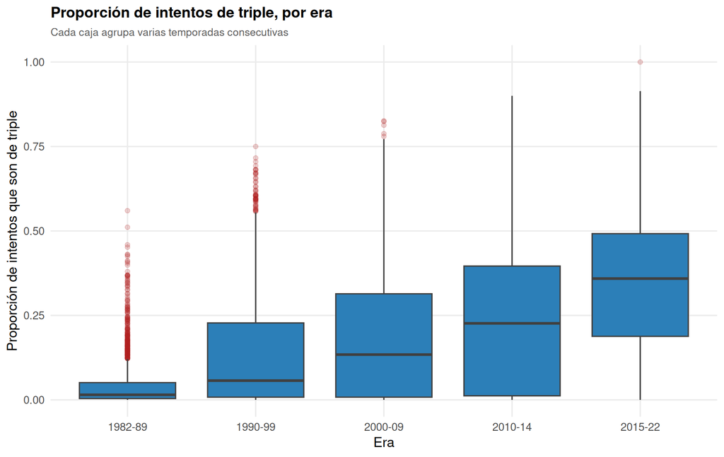

```r
ggplot(df, aes(x = era, y = porc_intentos_triple)) +
  geom_boxplot(fill = col_punto, color = "grey25", outlier.color = col_outlier,
               outlier.alpha = 0.2, na.rm = TRUE) +
  labs(
    title = "Proporción de intentos de triple, por era",
    subtitle = "Cada caja agrupa varias temporadas consecutivas",
    x = "Era", y = "Proporción de intentos que son de triple"
  ) +
  tema_biv
```

```r
byyear %>%
  filter(temporada %in% c(1982, 1995, 2005, 2014, 2018, 2022)) %>%
  select(temporada, media_3pa) %>%
  kable(
    digits = c(0, 3),
    col.names = c("Temporada", "Proporción media de intentos de triple"),
    caption = "Referencia rápida: el triple pasó de ser un recurso marginal a casi 4 de cada 10 intentos"
  ) %>%
  kable_styling(bootstrap_options = c("striped", "condensed"), full_width = FALSE)
```

Referencia rápida: el triple pasó de ser un recurso marginal a casi 4 de cada 10 intentos

| Temporada | Proporción media de intentos de triple |
| --- | --- |
| 1982 | 0.027 |
| 1995 | 0.165 |
| 2005 | 0.172 |
| 2014 | 0.267 |
| 2018 | 0.345 |
| 2022 | 0.397 |

## 12.6 5. Rebote (TRB%) vs. creación de juego (AST%): un trade-off posicional

```r
r_trb_ast <- cor(df$porc_rebotes_tot_disp, df$porc_asistencias_equipo, use = "pairwise.complete.obs")
q_trb75 <- quantile(df$porc_rebotes_tot_disp, 0.75, na.rm = TRUE)
q_ast75 <- quantile(df$porc_asistencias_equipo, 0.75, na.rm = TRUE)
```

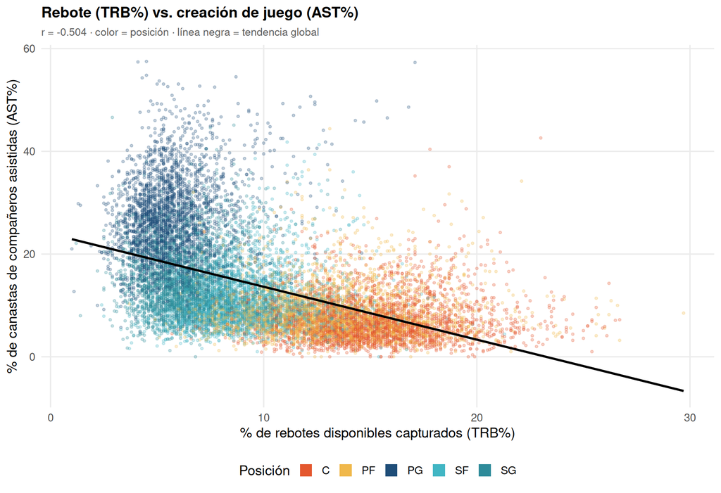

```r
ggplot(df, aes(x = porc_rebotes_tot_disp, y = porc_asistencias_equipo, color = posicion)) +
  geom_point(alpha = 0.25, size = 0.8, na.rm = TRUE) +
  geom_smooth(aes(group = 1), method = "lm", se = FALSE, color = "black", linewidth = 1, na.rm = TRUE) +
  scale_color_manual(values = paleta_posicion) +
  guides(color = guide_legend(title = "Posición", override.aes = list(shape = 15, size = 5, alpha = 1))) +
  labs(
    title = "Rebote (TRB%) vs. creación de juego (AST%)",
    subtitle = paste0("r = ", round(r_trb_ast, 3), " · color = posición · línea negra = tendencia global"),
    x = "% de rebotes disponibles capturados (TRB%)",
    y = "% de canastas de compañeros asistidas (AST%)"
  ) +
  tema_biv
```

```r
df %>%
  filter(porc_rebotes_tot_disp > q_trb75, porc_asistencias_equipo > q_ast75) %>%
  slice_max(valor_sobre_reemplazo, n = 5) %>%
  select(jugador, temporada, posicion, porc_rebotes_tot_disp, porc_asistencias_equipo, valor_sobre_reemplazo) %>%
  kable(
    digits = c(0, 0, 0, 1, 1, 1),
    col.names = c("Jugador", "Temporada", "Posición", "TRB% (rebotes capturados)", "AST% (asistencias repartidas)", "VORP (valor total aportado)"),
    caption = "Arquetipos híbridos: TRB% y AST% simultáneamente en el 25% más alto"
  ) %>%
  kable_styling(bootstrap_options = c("striped", "condensed"), full_width = FALSE)
```

Arquetipos híbridos: TRB% y AST% simultáneamente en el 25% más alto

| Jugador | Temporada | Posición | TRB% (rebotes capturados) | AST% (asistencias repartidas) | VORP (valor total aportado) |
| --- | --- | --- | --- | --- | --- |
| David Robinson | 1994 | C | 14.8 | 21.6 | 11.4 |
| Kevin Garnett | 2004 | PF | 20.1 | 24.4 | 10.0 |
| Nikola Jokić | 2022 | C | 23.0 | 42.6 | 9.8 |
| Russell Westbrook | 2017 | PG | 17.1 | 57.3 | 9.3 |
| Kevin Garnett | 2005 | PF | 20.3 | 27.1 | 9.1 |

**Interpretación:** la relación es negativa y de magnitud moderada (r = -0.504), y el color por posición explica por qué: los pívots dominan la esquina de TRB% alto y AST% bajo, mientras que los bases dominan la esquina opuesta. Nada en la fórmula de ninguna de las dos variables obliga a esta oposición —a diferencia de las identidades algebraicas detectadas en el análisis univariado—, por lo que la correlación negativa constituye un patrón real del juego y no un artefacto de cálculo. Este patrón corresponde a la especialización posicional clásica del baloncesto: el jugador que se ubica cerca del aro captura más rebotes porque ahí termina la mayoría de los lanzamientos fallados, mientras que el jugador que organiza el ataque reparte más asistencias porque tiene el balón en las manos con mayor frecuencia. Los pocos casos que aparecen en la esquina superior derecha —Nikola Jokić, Russell Westbrook o Kevin Garnett en algunas de sus temporadas— resultan estadísticamente atípicos precisamente porque combinan dos roles que el juego separa de forma sistemática, y esa rareza estadística es la base de por qué este tipo de jugadores suele describirse como generacional: no sobresalen en una sola dimensión, sino que alteran la estructura misma del rol que ocupan.

## 12.7 6. Protagonismo (USG%) vs. producción (puntos por partido)

Esta relación complementa la primera: contrasta el Porcentaje de Uso (`porc_uso_jugador`, USG%) con los puntos por partido (`puntos_pp`) para examinar si es posible anotar en volumen sin ser el protagonista ofensivo del equipo, es decir, sin necesitar un uso ofensivo alto.

```r
r_usg_pts <- cor(df$porc_uso_jugador, df$puntos_pp, use = "pairwise.complete.obs")
```

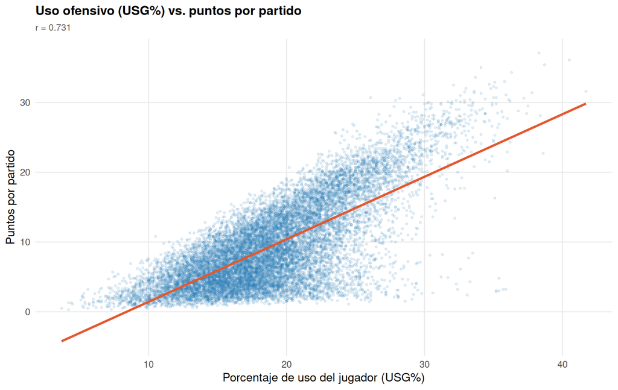

```r
ggplot(df, aes(x = porc_uso_jugador, y = puntos_pp)) +
  geom_point(alpha = 0.12, color = col_punto, size = 0.8, na.rm = TRUE) +
  geom_smooth(method = "lm", se = FALSE, color = col_ajuste, na.rm = TRUE) +
  labs(
    title = "Uso ofensivo (USG%) vs. puntos por partido",
    subtitle = paste0("r = ", round(r_usg_pts, 3)),
    x = "Porcentaje de uso del jugador (USG%)",
    y = "Puntos por partido"
  ) +
  tema_biv
```

```r
df %>%
  filter(
    porc_uso_jugador < quantile(porc_uso_jugador, 0.40, na.rm = TRUE),
    puntos_pp > quantile(puntos_pp, 0.75, na.rm = TRUE)
  ) %>%
  slice_max(puntos_pp, n = 5) %>%
  select(jugador, temporada, porc_uso_jugador, puntos_pp, porc_tiro_verdadero) %>%
  kable(
    digits = c(0, 0, 1, 1, 3),
    col.names = c("Jugador", "Temporada", "USG% (uso ofensivo)", "Puntos por partido", "TS% (eficiencia de tiro)"),
    caption = "Anotan mucho sin ser el protagonista ofensivo: bajo USG%, muchos puntos"
  ) %>%
  kable_styling(bootstrap_options = c("striped", "condensed"), full_width = FALSE)
```

Anotan mucho sin ser el protagonista ofensivo: bajo USG%, muchos puntos

| Jugador | Temporada | USG% (uso ofensivo) | Puntos por partido | TS% (eficiencia de tiro) |
| --- | --- | --- | --- | --- |
| Dan Majerle | 1993 | 17.3 | 16.9 | 0.573 |
| Harrison Barnes | 2021 | 17.2 | 16.1 | 0.626 |
| Michael Cage | 1987 | 17.1 | 15.7 | 0.579 |
| Danny Ainge | 1988 | 17.3 | 15.7 | 0.598 |
| Rudy Gobert | 2022 | 16.9 | 15.6 | 0.732 |

**Interpretación:** la correlación es fuerte (r = 0.731) y más alta que la observada entre USG% y TS%, en la dirección esperada: el volumen de tiro y el volumen de anotación comparten la misma raíz. No obstante, como en la primera relación, lo más informativo está fuera de la nube principal: existe un grupo de jugadores con USG% en el 40% más bajo del dataset que, aun así, anota en el 25% más alto. Ese grupo —Rudy Gobert anotando principalmente de cerca del aro con un TS% de 0.73, o tiradores como Dan Majerle y Harrison Barnes— representa un arquetipo de valor distinto al de la primera relación: no llevan el peso de crear su propio lanzamiento, pero convierten con alta eficiencia casi todo lo que reciben. Para la construcción de una plantilla, esta distinción equivale a la diferencia entre pagarle a un jugador por generar ofensiva y pagarle por capitalizar la ofensiva que otros generan; son dos habilidades distintas que `puntos_pp` por sí solo no distingue, pero que emergen con claridad al cruzarla con `porc_uso_jugador`.

## 12.8 7. Minutos totales vs. valor sobre el reemplazo (VORP)

Esta relación contrasta los minutos totales jugados en la temporada (`minutos_totales`) con el Valor Sobre el Jugador de Reemplazo (`valor_sobre_reemplazo`, VORP), que estima cuánto valor aportó un jugador durante toda la temporada en comparación con el mínimo que cualquier equipo podría conseguir gratuitamente en el mercado —un “jugador de reemplazo”—; a diferencia del PER, el VORP es un acumulado de toda la temporada y no una tasa por minuto, por lo que también premia jugar muchos minutos, no solo jugar bien. El análisis univariado ya señalaba a `minutos_totales` como control obligatorio para cualquier variable acumulada, y esta sección hace explícita esa relación con la variable de valor más agregada del panel.

```r
r_min_vorp <- cor(df$minutos_totales, df$valor_sobre_reemplazo, use = "pairwise.complete.obs")

tabla_decil <- df %>%
  mutate(decil_minutos = ntile(minutos_totales, 10)) %>%
  group_by(decil_minutos) %>%
  summarise(
    minutos_prom = mean(minutos_totales, na.rm = TRUE),
    vorp_prom = mean(valor_sobre_reemplazo, na.rm = TRUE),
    .groups = "drop"
  )
```

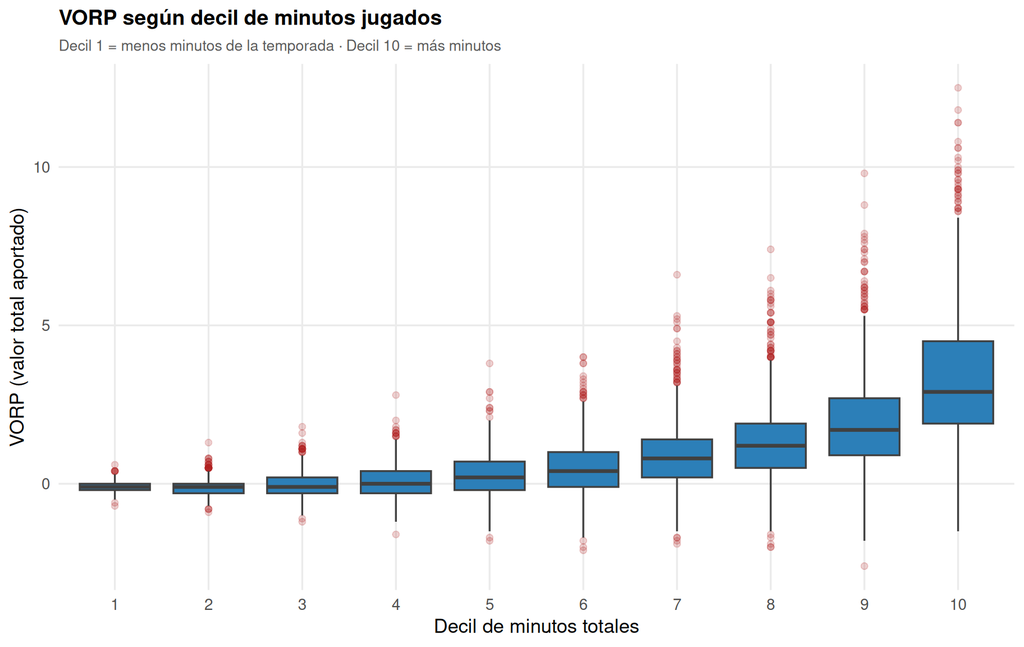

```r
df %>%
  mutate(decil_minutos = ntile(minutos_totales, 10)) %>%
  ggplot(aes(x = factor(decil_minutos), y = valor_sobre_reemplazo)) +
  geom_boxplot(fill = col_punto, color = "grey25", outlier.color = col_outlier,
               outlier.alpha = 0.2, na.rm = TRUE) +
  labs(
    title = "VORP según decil de minutos jugados",
    subtitle = "Decil 1 = menos minutos de la temporada · Decil 10 = más minutos",
    x = "Decil de minutos totales", y = "VORP (valor total aportado)"
  ) +
  tema_biv
```

```r
tabla_decil %>%
  kable(
    digits = c(0, 0, 2),
    col.names = c("Decil de minutos (1 = menos juega, 10 = más juega)", "Minutos promedio", "VORP promedio (valor total aportado)"),
    caption = "VORP promedio por decil de minutos jugados"
  ) %>%
  kable_styling(bootstrap_options = c("striped", "condensed"), full_width = FALSE)
```

VORP promedio por decil de minutos jugados

| Decil de minutos (1 = menos juega, 10 = más juega) | Minutos promedio | VORP promedio (valor total aportado) |
| --- | --- | --- |
| 1 | 182 | -0.09 |
| 2 | 402 | -0.11 |
| 3 | 681 | -0.07 |
| 4 | 968 | 0.05 |
| 5 | 1260 | 0.26 |
| 6 | 1552 | 0.47 |
| 7 | 1838 | 0.85 |
| 8 | 2143 | 1.27 |
| 9 | 2482 | 1.87 |
| 10 | 2920 | 3.30 |

## 12.9 8. Uso ofensivo (USG%) vs. pérdidas normalizadas

Esta relación pone a prueba una intuición común: que manejar más el balón —un Porcentaje de Uso (USG%) más alto— debería producir más pérdidas por jugada. Se examina con la versión normalizada de las pérdidas (`porc_perdidas_jugada`, pérdidas por cada 100 jugadas individuales) en lugar del conteo bruto por partido, para aislar el riesgo de pérdida por jugada del efecto puramente mecánico de jugar más minutos.

```r
r_usg_tov <- cor(df$porc_uso_jugador, df$porc_perdidas_jugada, use = "pairwise.complete.obs")
```

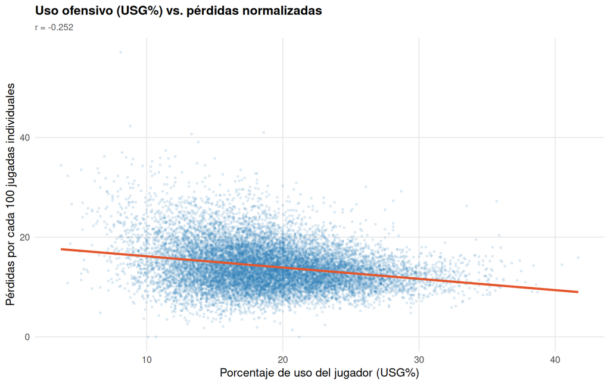

```r
ggplot(df, aes(x = porc_uso_jugador, y = porc_perdidas_jugada)) +
  geom_point(alpha = 0.12, color = col_punto, size = 0.7, na.rm = TRUE) +
  geom_smooth(method = "lm", se = FALSE, color = col_ajuste, na.rm = TRUE) +
  labs(
    title = "Uso ofensivo (USG%) vs. pérdidas normalizadas",
    subtitle = paste0("r = ", round(r_usg_tov, 3)),
    x = "Porcentaje de uso del jugador (USG%)",
    y = "Pérdidas por cada 100 jugadas individuales"
  ) +
  tema_biv
```

**Interpretación:** la correlación resulta negativa (r = -0.252), el signo contrario al que predeciría la intuición de que manejar más el balón implica perderlo con más frecuencia: a medida que sube el USG%, la tasa de pérdidas por jugada tiende a bajar levemente en lugar de subir. El resultado se explica al revisar la definición exacta de la variable: `porc_perdidas_jugada` normaliza las pérdidas por el número de jugadas individuales en las que participa el jugador, no solo por sus minutos jugados, y un jugador con USG% alto suele ser también un manejador de balón más hábil, dado que llegar a ese rol exige superar un filtro de selección —a un base con mal manejo de balón difícilmente se le asigna un USG% alto durante muchas temporadas—. Este hallazgo no contradice lo observado en la relación 3, donde sí se confirma que los bases pierden más balones por partido que los pívots: son dos preguntas distintas, pérdidas absolutas asociadas al rol (relación 3) frente a riesgo de pérdida por jugada individual una vez que el jugador ya tiene el balón (esta relación). La lección metodológica de fondo es que, antes de interpretar el signo de una correlación, es necesario revisar cómo está definida exactamente cada variable involucrada.

## 12.10 9. Porcentaje de victorias del equipo vs. impacto defensivo individual (DBPM)

Esta relación contrasta el porcentaje de victorias del equipo (`porc_victorias_equipo`) con el Box Plus/Minus defensivo (`masmenos_defensivo`, DBPM), que estima cuántos puntos por cada 100 posesiones aporta o resta un jugador únicamente en la faceta defensiva del juego, en comparación con un jugador promedio de la liga. Las métricas defensivas individuales se cuentan entre las menos fiables de la estadística de baloncesto porque dependen en buena medida del sistema táctico del equipo; esta relación sirve como control de validez para comprobar si los buenos defensores solo aparecen en equipos ganadores, o si el dato individual sobrevive incluso en equipos con mal desempeño colectivo.

```r
r_win_dbpm <- cor(df$porc_victorias_equipo, df$masmenos_defensivo, use = "pairwise.complete.obs")
q_dbpm85 <- quantile(df$masmenos_defensivo, 0.85, na.rm = TRUE)
q_win25 <- quantile(df$porc_victorias_equipo, 0.25, na.rm = TRUE)
```

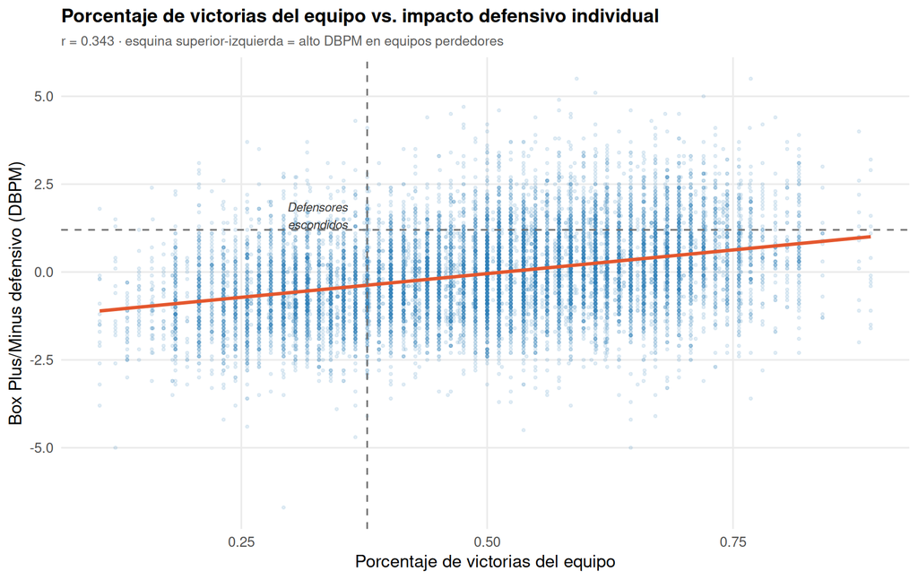

```r
ggplot(df, aes(x = porc_victorias_equipo, y = masmenos_defensivo)) +
  geom_point(alpha = 0.12, color = col_punto, size = 0.7, na.rm = TRUE) +
  geom_smooth(method = "lm", se = FALSE, color = col_ajuste, na.rm = TRUE) +
  geom_hline(yintercept = q_dbpm85, linetype = "dashed", color = "grey45") +
  geom_vline(xintercept = q_win25, linetype = "dashed", color = "grey45") +
  annotate(
    "text", x = q_win25 - 0.02, y = q_dbpm85 + 0.4,
    label = "Defensores\nescondidos", hjust = 1, size = 3.2,
    fontface = "italic", color = "grey20"
  ) +
  labs(
    title = "Porcentaje de victorias del equipo vs. impacto defensivo individual",
    subtitle = paste0("r = ", round(r_win_dbpm, 3), " · esquina superior-izquierda = alto DBPM en equipos perdedores"),
    x = "Porcentaje de victorias del equipo", y = "Box Plus/Minus defensivo (DBPM)"
  ) +
  tema_biv
```

```r
df %>%
  filter(masmenos_defensivo > q_dbpm85, porc_victorias_equipo < q_win25) %>%
  slice_max(masmenos_defensivo, n = 5) %>%
  select(jugador, temporada, equipo, masmenos_defensivo, porc_victorias_equipo) %>%
  kable(
    digits = c(0, 0, 0, 1, 3),
    col.names = c("Jugador", "Temporada", "Equipo", "DBPM (impacto defensivo)", "% victorias del equipo"),
    caption = "\"Defensores escondidos\": DBPM alto en equipos con pocas victorias"
  ) %>%
  kable_styling(bootstrap_options = c("striped", "condensed"), full_width = FALSE)
```

“Defensores escondidos”: DBPM alto en equipos con pocas victorias

| Jugador | Temporada | Equipo | DBPM (impacto defensivo) | % victorias del equipo |
| --- | --- | --- | --- | --- |
| Mark Eaton | 1983 | UTA | 4.3 | 0.366 |
| Eric Murdock | 1997 | DEN | 3.7 | 0.256 |
| Andrei Kirilenko | 2005 | UTA | 3.7 | 0.317 |
| Kyle Lowry | 2007 | MEM | 3.5 | 0.268 |
| Quinn Buckner | 1986 | IND | 3.4 | 0.317 |

**Interpretación:** la correlación es positiva pero de magnitud moderada (r = 0.343), sensiblemente más débil que la observada entre `porc_victorias_equipo` y `margen_victoria` (r > 0.96), identificada en el análisis univariado como la expresión de la expectativa pitagórica del baloncesto. Existe, además, un grupo identificable en la esquina superior izquierda del gráfico: jugadores con DBPM en el 15% más alto del dataset que, sin embargo, juegan en equipos ubicados en el 25% con menos victorias. Una correlación moderada —ni cercana a cero ni extremadamente alta— es justamente lo que cabría esperar si el DBPM mide algo real del jugador además del contexto de su equipo: si esta métrica fuera resultado exclusivo del sistema táctico, no debería existir un grupo estable de jugadores con DBPM alto en equipos de bajo desempeño, como Mark Eaton, un joven Kyle Lowry o Andrei Kirilenko. Estos casos muestran que la habilidad defensiva individual puede sostenerse incluso sin un equipo ganador alrededor, lo que constituye evidencia de que el DBPM conserva señal aprovechable para identificar a un defensor infravalorado en un equipo con mal récord, aunque siempre debe interpretarse junto con el contexto de equipo y nunca de forma aislada.

## 12.11 10. Años de experiencia vs. eficiencia, controlando por edad de entrada

Un jugador universitario que ingresa a la liga a los 22 años y otro que ingresa a los 19 no son comparables en su primera temporada, porque “experiencia” y “edad” están correlacionadas pero no son lo mismo. Esta relación aísla ese efecto construyendo dos variables derivadas que no existen directamente en `nbaFINAL.csv`: los años de experiencia en la liga y la edad de entrada de cada jugador.

```r
entrada <- df %>%
  group_by(jugador) %>%
  slice_min(temporada, n = 1, with_ties = FALSE) %>%
  ungroup() %>%
  select(jugador, edad_entrada = edad)

df_exp <- df %>%
  left_join(entrada, by = "jugador") %>%
  group_by(jugador) %>%
  mutate(experiencia = temporada - min(temporada)) %>%
  ungroup() %>%
  mutate(
    categoria_entrada = case_when(
      edad_entrada <= 19 ~ "<=19",
      edad_entrada <= 21 ~ "20-21",
      edad_entrada <= 23 ~ "22-23",
      TRUE ~ "24+"
    ),
    categoria_entrada = factor(categoria_entrada, levels = c("<=19", "20-21", "22-23", "24+"))
  )
```

```r
df_exp %>%
  distinct(jugador, categoria_entrada) %>%
  count(categoria_entrada) %>%
  kable(
    col.names = c("Edad de entrada a la liga", "Número de jugadores"),
    caption = "Tamaño de cada grupo de edad de entrada"
  ) %>%
  kable_styling(bootstrap_options = c("striped", "condensed"), full_width = FALSE)
```

Tamaño de cada grupo de edad de entrada

| Edad de entrada a la liga | Número de jugadores |
| --- | --- |
| <=19 | 132 |
| 20-21 | 515 |
| 22-23 | 1245 |
| 24+ | 803 |

```r
df_exp %>%
  filter(experiencia <= 5) %>%
  group_by(categoria_entrada, experiencia) %>%
  summarise(PER_promedio = mean(indice_eficiencia, na.rm = TRUE), .groups = "drop") %>%
  pivot_wider(names_from = categoria_entrada, values_from = PER_promedio) %>%
  kable(
    digits = 2,
    caption = "PER promedio según años de experiencia, por edad de entrada a la liga"
  ) %>%
  kable_styling(bootstrap_options = c("striped", "condensed"), full_width = FALSE)
```

PER promedio según años de experiencia, por edad de entrada a la liga

| experiencia | <=19 | 20-21 | 22-23 | 24+ |
| --- | --- | --- | --- | --- |
| 0 | 12.05 | 12.33 | 11.38 | 11.81 |
| 1 | 13.57 | 14.31 | 12.82 | 12.99 |
| 2 | 14.91 | 15.40 | 13.61 | 13.51 |
| 3 | 16.95 | 16.08 | 14.02 | 13.41 |
| 4 | 17.19 | 16.61 | 14.07 | 13.38 |
| 5 | 17.83 | 16.63 | 13.99 | 13.11 |

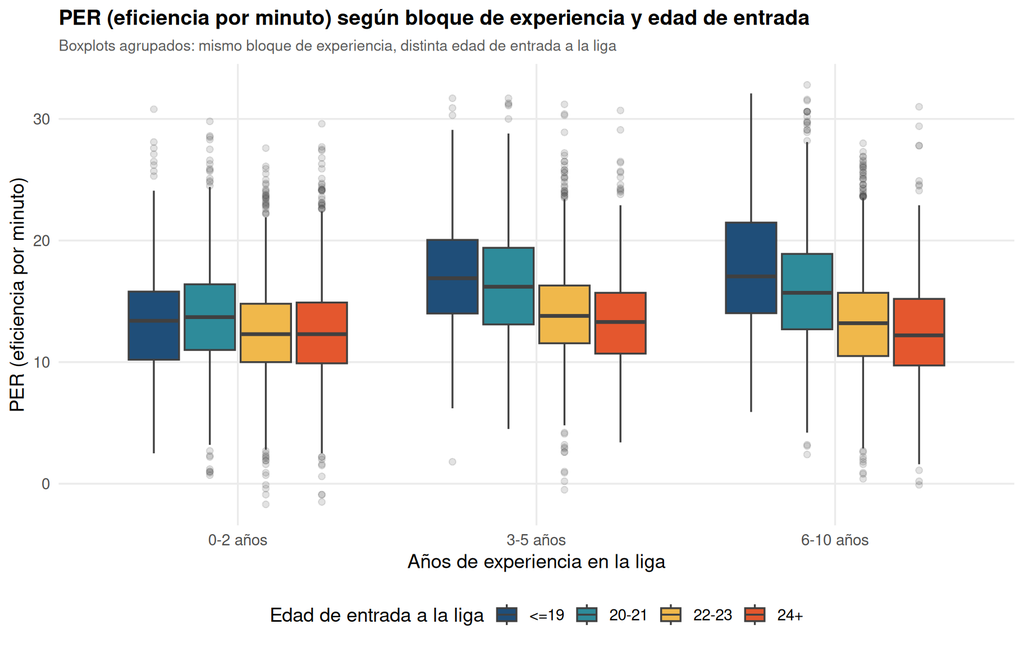

```r
df_exp %>%
  filter(experiencia <= 10) %>%
  mutate(
    bloque_experiencia = cut(
      experiencia,
      breaks = c(-1, 2, 5, 10),
      labels = c("0-2 años", "3-5 años", "6-10 años")
    )
  ) %>%
  ggplot(aes(x = bloque_experiencia, y = indice_eficiencia, fill = categoria_entrada)) +
  geom_boxplot(color = "grey25", outlier.alpha = 0.15, na.rm = TRUE) +
  scale_fill_manual(values = paleta_entrada, name = "Edad de entrada a la liga") +
  labs(
    title = "PER (eficiencia por minuto) según bloque de experiencia y edad de entrada",
    subtitle = "Boxplots agrupados: mismo bloque de experiencia, distinta edad de entrada a la liga",
    x = "Años de experiencia en la liga", y = "PER (eficiencia por minuto)"
  ) +
  tema_biv
```

**Interpretación:** en el bloque de debut (0-2 años de experiencia) los cuatro grupos presentan valores relativamente parejos (medianas de PER entre 12.3 y 13.7). Al llegar al bloque de 3-5 años, sin embargo, las cajas del grupo que ingresó con 19 años o menos ya se separan hacia arriba (mediana aproximada de 16.9), mientras que las del grupo que ingresó con 24 años o más apenas se desplazan (mediana aproximada de 13.3); para el bloque de 6-10 años la separación es aún mayor. Esta brecha, que no existe en el momento del debut, se abre con cada bloque adicional de experiencia, pero no debe interpretarse como evidencia de que ingresar joven a la liga causa un mejor desarrollo. Se trata, ante todo, de un caso de sesgo de selección: para que un equipo arriesgue un cupo de plantilla en un jugador de 18 o 19 años, este ya debe ser un talento excepcional —un futuro All-Star potencial, seleccionado alto en el draft—, mientras que ingresar a la NBA por primera vez a los 24 años o más suele indicar una trayectoria marginal: un jugador de rol, un fichaje internacional tardío o un suplente que apenas asegura un contrato. El grupo que ingresa joven no mejora más rápido por efecto de la edad en sí misma: ya era mejor desde el primer año, como consecuencia del proceso de selección que lo llevó a la liga tan pronto. Es exactamente el tipo de variable de confusión —la edad de entrada actuando como proxy del talento inicial— que una lectura causal ingenua de “la experiencia mejora el rendimiento” pasaría por alto.

## 12.12 11. Anotación (puntos por partido) vs. creación de juego (asistencias por partido), por posición

Esta relación contrasta los puntos por partido (`puntos_pp`) con las asistencias por partido (`asistencias_pp`). La gestión de las posesiones sugiere un compromiso lógico entre ambas variables: si un jugador lanza a canasta, no puede asistir a un compañero en esa misma jugada, por lo que sería razonable esperar que los perfiles de alta anotación registren pocas asistencias, y viceversa, separando a los finalizadores de los distribuidores de juego. Se colorea por `posicion` para examinar si ese supuesto compromiso se cumple dentro de cada rol o si, como en la relación 5, existe un grupo que rompe la regla.

```r
r_pts_ast <- cor(df$puntos_pp, df$asistencias_pp, use = "pairwise.complete.obs")

tabla_pts_ast <- df %>%
  group_by(posicion) %>%
  summarise(
    puntos_mediana = median(puntos_pp, na.rm = TRUE),
    asistencias_mediana = median(asistencias_pp, na.rm = TRUE),
    .groups = "drop"
  ) %>%
  arrange(asistencias_mediana)

orden_pos_ast2 <- tabla_pts_ast$posicion

q_pts75 <- quantile(df$puntos_pp, 0.75, na.rm = TRUE)
q_ast75 <- quantile(df$asistencias_pp, 0.75, na.rm = TRUE)
```

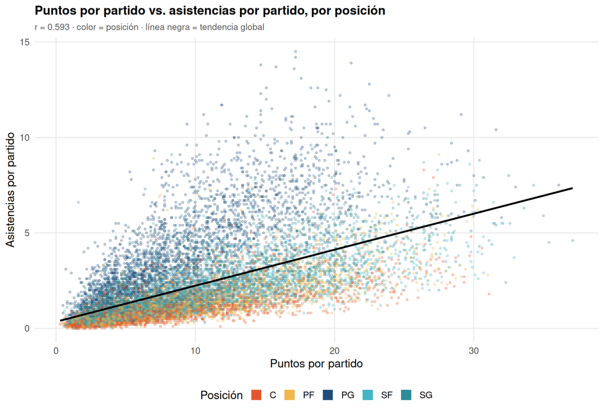

```r
ggplot(df, aes(x = puntos_pp, y = asistencias_pp, color = posicion)) +
  geom_point(alpha = 0.25, size = 0.8, na.rm = TRUE) +
  geom_smooth(aes(group = 1), method = "lm", se = FALSE, color = "black", linewidth = 1, na.rm = TRUE) +
  scale_color_manual(values = paleta_posicion) +
  guides(color = guide_legend(title = "Posición", override.aes = list(shape = 15, size = 5, alpha = 1))) +
  labs(
    title = "Puntos por partido vs. asistencias por partido, por posición",
    subtitle = paste0("r = ", round(r_pts_ast, 3), " · color = posición · línea negra = tendencia global"),
    x = "Puntos por partido", y = "Asistencias por partido"
  ) +
  tema_biv
```

```r
tabla_pts_ast %>%
  kable(
    digits = c(0, 1, 1),
    col.names = c("Posición", "Puntos/partido (mediana)", "Asistencias/partido (mediana)"),
    caption = "Puntos y asistencias por partido, por posición (ordenado de menor a mayor asistencias)"
  ) %>%
  kable_styling(bootstrap_options = c("striped", "condensed"), full_width = FALSE)
```

Puntos y asistencias por partido, por posición (ordenado de menor a mayor asistencias)

| Posición | Puntos/partido (mediana) | Asistencias/partido (mediana) |
| --- | --- | --- |
| C | 6.4 | 0.8 |
| PF | 7.5 | 1.0 |
| SF | 8.6 | 1.4 |
| SG | 9.1 | 1.9 |
| PG | 8.4 | 3.8 |

```r
df %>%
  filter(puntos_pp > q_pts75, asistencias_pp > q_ast75) %>%
  slice_max(valor_sobre_reemplazo, n = 6) %>%
  select(jugador, temporada, posicion, puntos_pp, asistencias_pp, valor_sobre_reemplazo) %>%
  kable(
    digits = c(0, 0, 0, 1, 1, 1),
    col.names = c("Jugador", "Temporada", "Posición", "Puntos/partido", "Asistencias/partido", "VORP (valor total aportado)"),
    caption = "Anotan y asisten a la vez: puntos y asistencias simultáneamente en el 25% más alto"
  ) %>%
  kable_styling(bootstrap_options = c("striped", "condensed"), full_width = FALSE)
```

Anotan y asisten a la vez: puntos y asistencias simultáneamente en el 25% más alto

| Jugador | Temporada | Posición | Puntos/partido | Asistencias/partido | VORP (valor total aportado) |
| --- | --- | --- | --- | --- | --- |
| Michael Jordan | 1988 | SG | 35.0 | 5.9 | 12.5 |
| LeBron James | 2009 | SF | 28.4 | 7.2 | 11.8 |
| Michael Jordan | 1989 | SG | 32.5 | 8.0 | 11.4 |
| David Robinson | 1994 | C | 29.8 | 4.8 | 11.4 |
| Michael Jordan | 1991 | SG | 31.5 | 5.5 | 10.8 |
| Michael Jordan | 1987 | SG | 37.1 | 4.6 | 10.6 |
| Michael Jordan | 1990 | SG | 33.6 | 6.3 | 10.6 |

**Interpretación:** la correlación es r = 0.593, positiva y de magnitud moderada, el signo contrario al que predeciría un compromiso estricto entre anotar y asistir. La tabla por posición explica por qué: los bases (PG) tienen una mediana de asistencias muy por encima del resto (3.8, frente a 0.8-1.9 en las demás posiciones), pero sus puntos por partido no son los más bajos, sino que se ubican en el mismo rango que los de aleros y ala-pívots. Son los bases quienes empujan la relación hacia arriba al combinar buen volumen de anotación con muchas asistencias, y no un reparto estricto entre anotar o asistir dentro de cada posición. El grupo que aparece simultáneamente en el 25% más alto de ambas variables (tabla anterior) no está dominado por bases, como sugeriría la intuición de que el base es quien reparte, sino por escoltas y aleros con el balón en las manos — Michael Jordan y LeBron James concentran varias de las mejores temporadas de esta tabla—, jugadores que funcionan como el principal generador ofensivo de su equipo sin ocupar formalmente la posición de base. Para la construcción de una plantilla, esto confirma que anotador y creador de juego no son roles excluyentes que dependan de la posición asignada, sino habilidades que algunos jugadores de élite combinan a la vez, y que el dato de posición por sí solo no captura.

# 13 Conclusiones del análisis bivariado

- **La correlación de Pearson resume bien algunas relaciones y esconde otras por completo.** USG% vs. TS% (relación 1) tiene r ≈ 0 y, aun así, sus extremos distinguen a las superestrellas de los anotadores ineficientes; edad vs. PER (relación 2) tiene r ≈ 0 mientras la curva real sube, hace pico y baja. En ambos casos, considerar únicamente el coeficiente habría llevado a concluir de forma errónea que no existe relación.
- **El signo de una correlación puede resultar contraintuitivo si no se revisa la definición exacta de la variable.** USG% vs. pérdidas normalizadas (relación 8) es negativa, contrario a la intuición de que manejar más el balón implica más riesgo de pérdida; la explicación está en cómo se normaliza la variable y en el sesgo de selección de quién llega a tener un USG% alto.
- **La posición es la variable de confusión más frecuente en el baloncesto.** Asistencias vs. pérdidas (relación 3) y rebote vs. asistencias (relación 5) solo se interpretan correctamente controlando o coloreando por posición; comparar entre posiciones sin ese control repite el mismo error de comparar grupos heterogéneos identificado en el análisis univariado.
- **Las variables de oportunidad (minutos) y de contexto (equipo) inflan relaciones que aparentan ser puramente de mérito individual.** Minutos vs. VORP (relación 7) y porcentaje de victorias del equipo vs. DBPM (relación 9) muestran que una parte del valor y del impacto defensivo medidos depende de decisiones ajenas al jugador —cuánto lo hace jugar el entrenador, qué tan bueno es su equipo— y no exclusivamente de su talento individual.
- **El cambio a través del tiempo puede manifestarse como un quiebre y no como una tendencia suave.** La proporción de intentos de triple (relación 4) no aumentó de forma gradual durante las 41 temporadas del dataset: existe un punto identificable donde el ritmo de cambio se acelera, y cualquier comparación entre épocas debe tenerlo en cuenta.
- **Una variable derivada puede aislar una confusión que ninguna columna original resuelve por sí sola.** “Experiencia” y “edad de entrada” (relación 10) no existen en `nbaFINAL.csv`; construirlas fue necesario para distinguir el efecto del desarrollo del efecto del sesgo de selección de quién llega joven a la liga.
- **Un supuesto compromiso entre dos habilidades no siempre se cumple.** Puntos vs. asistencias por partido (relación 11) es positiva (r ≈ 0.59) y no negativa: anotar y crear juego comparten una causa común —los minutos y el protagonismo ofensivo del jugador—, y son los bases quienes empujan la relación hacia arriba, no una compensación general entre roles. Los pocos jugadores que dominan ambas variables a la vez (Michael Jordan, LeBron James) tampoco son bases, lo que confirma que anotador y creador de juego son habilidades, no posiciones.